# 심박수 손목시계의 정확도: 상관, 단순 선형회귀, 측정오차

Wallen MP, Gomersall SR, Keating SE, Wisløff U, Coombes JS. Accuracy of Heart Rate Watches: Implications for Weight Management. *PLoS ONE* 2016;11(5):e0154420. [doi:10.1371/journal.pone.0154420](https://doi.org/10.1371/journal.pone.0154420) · 공개 자료 [S1 Dataset](https://doi.org/10.1371/journal.pone.0154420.s001)

의생명과학프로그래밍 6주차 · 주 실행 `R1-20261025` · 탐색 실행 `R2-20261025` · 자료 버전 `wallen-hr-331013dc4e56eb03e99b` · 보고서 생성 2026-10-25 17:09

## 1. 결과 요약

**네 기기의 약 58분 평균 HR은 ECG와 강하게 상관했지만(Pearson r 0.74–0.95), 모두 평균적으로 낮게 읽었다(bias -9.3 ~ -1.3 bpm). 상관이 높다는 것과 값이 일치한다는 것은 다르다.**

Apple Watch (n = 22)

r = 0.953 · bias -1.3 bpm

고정 95% LoA -9.8 ~ 7.3 bpm · MAE 2.5

Fitbit Charge HR (n = 22)

r = 0.812 · bias -9.3 bpm

고정 95% LoA -25.9 ~ 7.3 bpm · MAE 10.6

Samsung Gear S (n = 22)

r = 0.743 · bias -7.0 bpm

고정 95% LoA -27.2 ~ 13.1 bpm · MAE 9.7

Mio Alpha (n = 22)

r = 0.870 · bias -4.3 bpm

고정 95% LoA -18.5 ~ 9.8 bpm · MAE 4.8

| 기기 | Pearson r [95% CI] | OLS 기울기 [95% CI] | 평균오차 bias [95% CI] (bpm) | 고정 95% LoA (bpm) | MAE (bpm) |
| --- | --- | --- | --- | --- | --- |
| Apple Watch | 0.953 [0.888, 0.981] | 0.926 [0.788, 1.063] | -1.26 [-3.20, 0.68] | -9.84 ~ 7.32 | 2.53 |
| Fitbit Charge HR | 0.812 [0.594, 0.919] | 0.644 [0.428, 0.860] | -9.32 [-13.08, -5.56] | -25.94 ~ 7.30 | 10.55 |
| Samsung Gear S | 0.743 [0.467, 0.887] | 0.709 [0.411, 1.007] | -7.05 [-11.60, -2.50] | -27.15 ~ 13.06 | 9.74 |
| Mio Alpha | 0.870 [0.709, 0.945] | 0.946 [0.696, 1.196] | -4.34 [-7.54, -1.14] | -18.49 ~ 9.80 | 4.81 |

분모: 기기별 참가자 n = 22 (88쌍은 22명이 4기기를 찬 반복 구조이며 88명의 독립 표본이 아님). 오차 = 시계 − ECG, 음수 = 과소측정. r의 CI는 Fisher z, bias의 CI는 t 분포, LoA는 bias ± 1.96 SD(고정, 분석자 계산)로 서로 다른 구간이다.

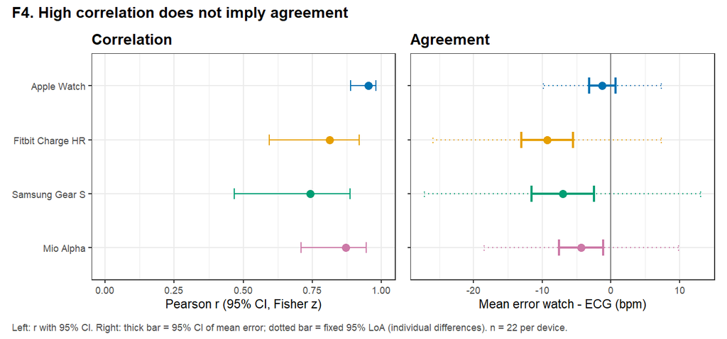

F4. 왼쪽: 기기별 Pearson r과 95% CI. 오른쪽: 굵은 막대 = 평균오차 95% CI, 점선 = 고정 95% LoA. 상관 순서와 오차 크기 순서가 같지 않다.

원문 Table 1의 HR 값과의 대조: 사전에 정한 허용오차로 **39개 반올림 일치, 7개 불일치, 7개 비교 불가**(부분 일치). 불일치 값은 모두 반올림된 r·bias·SD로 계산하면 재현된다(탐색적, 저자 구현 미확인). 자세한 내용은 HR06.

## 2. 자료 흐름

**원자료 xlsx**Heart_Rate 시트 22행 × 13열  
SHA-256 50cae0d20ded…

→

**HR01 88쌍**열 위치 매핑, ECG 짝 확인 44/44  
입력 88 · 제외 0 · 사용 88

→

**HR02–HR04 기기별 n = 22**Pearson r · OLS · 측정오차·LoA  
F1–F4

→

**HR05 보조 진단**잔차 · Q–Q · Cook · 한 명씩 제외(21명 × 22회)  
F5–F7

→

**HR06 원문 대조**R1 사전 규칙 → R2 탐색 후보  
Table 1 HR

→

**HR07 문제·한계**문제 20건, 검토 범위

위 순서는 읽기 순서다. 실행 의존성은 HR01 → {HR02, HR03, HR04} → HR05, HR06이며, R2는 R1 표만 입력으로 쓴다 (`analysis/stage_registry.json`).

## 3. 학습 단계 HR01–HR07

각 단계는 **CONCEPT / 일반 통계 개념**(가상 숫자만 사용)을 먼저, **PAPER / 논문·실제 데이터 적용**(run 표에서 채운 실제 수치)을 다음에 둔다. 두 패널 모두 원래 MD의 내용 전체이며, 각 패널 아래에서 MD 원문을 보거나 저장할 수 있다.

**학습 읽기 지도** (docs/learning/00-학습문서읽기지도.md)**

# 00 · 학습 문서 읽기 지도 — Wallen et al. (2016) 심박수 시계의 정확도

> 이 폴더(`docs/learning/`)가 6주차 학습 문서의 정본이다. 최종 전달물은 최종분석보고서.html 한 파일이며, 이 MD들을 단계마다 CONCEPT → PAPER 패널로 담고 있다. 주 실행: `R1-20261025` · 탐색 실행: `R2-20261025` · 자료 버전: `wallen-hr-331013dc4e56eb03e99b` · R version 4.6.1 (2026-06-24 ucrt)

## 한 문장 요약

22명이 4종 손목시계를 찬 약 58분 실험에서 시계의 **평균 HR**은 ECG와 강하게 상관했지만(Pearson r 0.74–0.95), 네 기기 모두 평균적으로 낮게 읽었다(bias -9.3 ~ -1.3 bpm). **상관이 높다고 값이 같지는 않다.**

## 읽는 순서 (학습 순서이며 저자의 실행 순서가 아님)

| 단계 | 일반 개념 CONCEPT | 논문·실제 적용 PAPER | 핵심 산출물 |
| --- | --- | --- | --- |
| HR01 | 자료형·짝·관측 단위 | Key·열 매핑·88쌍 | `hr01_pairs_88.csv` |
| HR02 | 산점도·Pearson·CI·Spearman | 실제 상관, 원문 통계 종류 구분 | F1, `hr02_correlation.csv` |
| HR03 | 최소제곱·잔차·R²·구간 | 시계~ECG OLS vs 원문 BA 회귀 | F1, `hr03_ols.csv` |
| HR04 | bias·MAE·RMSE·Bland–Altman | 실제 오차, 고정 LoA vs 원문 Mio 가변 LoA | F2–F4, `hr04_error.csv` |
| HR05 | 잔차·Q–Q·영향점·민감도 | 전원 유지, 한 명씩 제외 시나리오 | F5–F7, `hr05_*.csv` |
| HR06 | 같은 정의의 비교·반올림 | Table 1 대조와 반올림 후보 | `hr06_*.csv` |
| HR07 | 문제 추적·검증 범위·한계 | 문제 원장·판정·남은 제한 | `memory/issues.json` |

실행 의존성(읽기 순서와 별개): HR01 → {HR02, HR03, HR04} → HR05(HR03 모형, HR04 오차 사용) → HR06(HR02, HR04 사용) → R2 후보(R1 표만 사용). 자세한 것은 `analysis/stage_registry.json`.

## 현재 재현 수준

- 원문 Table 1 HR 블록: 사전 규칙으로 **부분 일치**(39개 일치, 7개 불일치, 7개 비교 불가). 불일치는 모두 반올림된 중간값으로 계산한 경로와 호환된다(탐색적, 저자 구현 미확인).
- 과제 범위(산점도, Pearson, OLS, 측정오차, 지정 그림): 모두 구현했고, 별도 문맥 코드 감사에서 결과를 바꾸는 오류가 없었다.

## 중요한 발견

1. Samsung의 원문 0.67은 Spearman ρ이고, 과제의 Pearson r은 0.743이다. 서로 다른 통계량이다.
2. Fitbit은 r = 0.81인데 22명 중 21명을 낮게 읽었고, 기울기 0.64(CI가 1을 포함하지 않음)로 HR이 높을수록 더 낮게 읽는 모양이다.
3. 원문 HR 표의 파생값(CI 경계, LoA)은 반올림된 r·bias·SD로 계산한 값과 호환된다.

## 남은 의문

ISS-03(15초·활동별 자료 없음), ISS-06(정규성 판정 방법), ISS-11(Fitbit 체계적 편향 서술과 표의 상충), ISS-15(Python 교차검증 미실시), ISS-18(공식 URL 재다운로드 대조 안 함). 전체는 HR07-paper.

**MD 원문 보기 (docs/learning/00-학습문서읽기지도.md)**

### HR01 · 자료 구조와 88쌍

질문: 한 행은 무엇이고, 시계 HR은 어느 ECG 값과 짝인가? 분모는 몇인가?

CONCEPT / 일반 통계 개념

# HR01 · CONCEPT — 자료형, 변수, 단위, 짝, 관측 단위와 독립 단위

> 일반 통계 개념 페이지. 이 페이지의 숫자는 모두 **🧪 가상 예제**이며 실제 자료가 아니다. 실제 적용은 HR01-paper.

## 입력

- 엑셀 같은 표 하나. 행과 열이 있고, 각 칸(셀)에는 숫자나 글자가 들어 있다.
- 코드북(변수 설명서): 열 이름, 뜻, 단위, 허용값을 적어 둔 문서.

## 이번 질문

분석을 시작하기 전에 "**한 행은 무엇인가, 무엇과 무엇을 짝지어 비교하는가, 몇 개의 독립된 정보가 있는가**"를 정한다. 이걸 틀리면 뒤의 모든 통계가 틀린다.

## 방법과 이유

### 용어

| 용어 | 뜻 | 이 주제에서의 예 |
| --- | --- | --- |
| 자료형 | 숫자(연속형), 정수, 범주형, 글자 | 심박수 = 연속형 숫자, 기기 이름 = 범주형 |
| 단위 | 숫자가 무엇을 세는지 | bpm(분당 박동 수) |
| 짝(pair) | 같은 대상·같은 시간에 두 방법으로 잰 값 한 쌍 | (시계 값, 기준 ECG 값) |
| 관측 단위 | 표의 한 행이 나타내는 것 | "한 사람이 한 기기를 찬 한 번의 측정" |
| 독립 단위 | 서로 정보가 겹치지 않는 단위 | 사람. 같은 사람의 여러 행은 서로 닮는다 |
| 넓은 형식 / 긴 형식 | 기기마다 열을 따로 둔 표 / 기기를 한 열의 값으로 내린 표 | 4기기 × 3열 → `기기, 시계값, 기준값` |

### 짝을 짓는 이유

측정 비교는 "같은 순간의 같은 사람"을 두 방법으로 잰 값끼리만 의미가 있다. 다른 날 잰 기준값과 짝지으면 측정오차에 **날짜 차이**가 섞인다.

### 🧪 가상 예제: 넓은 표를 긴 표로

가상의 2명이 시계 A, B를 각각 다른 날(trial) 찼다고 하자.

| id | A_시계 | A_기준 | A_trial | B_시계 | B_기준 | B_trial |
| --- | --- | --- | --- | --- | --- | --- |
| 1 | 71 | 70 | 1 | 82 | 85 | 2 |
| 2 | 90 | 92 | 2 | 64 | 65 | 1 |

긴 표로 바꾸면 4행이 된다.

| id | 기기 | trial | 시계 | 기준 | 오차 = 시계 − 기준 |
| --- | --- | --- | --- | --- | --- |
| 1 | A | 1 | 71 | 70 | +1 |
| 1 | B | 2 | 82 | 85 | −3 |
| 2 | A | 2 | 90 | 92 | −2 |
| 2 | B | 1 | 64 | 65 | −1 |

- 행은 4개지만 **사람은 2명**이다. 기기 A만 보면 n = 2, B만 봐도 n = 2.
- 4행을 "독립 표본 4개"로 세면 표준오차가 실제보다 작게 나와 지나친 확신을 준다.

### 셀 값과 표시값

엑셀은 숫자를 2진 부동소수로 저장한다. 화면에 `78.07`로 보이는 값이 파일 안에서는 `78.069999999999993`일 수 있다. 같은 수를 가리키므로 **값을 바꾸지 말고** 원래 저장 문자열과 표시 자릿수를 함께 기록하면 된다.

### 가정과 대안

- 가정: 같은 행의 두 값은 같은 시간 구간을 측정했다.
- 대안 질문: "사람마다 여러 번 쟀다면?" → 반복측정(혼합모형)이나 사람 단위 요약이 답하는 질문이다. 이 주제에서는 사람 × 기기당 값이 하나뿐이라 기기별로 나눠 n = 사람 수로 분석한다.

## 출력

- 긴 표(행 = 사람 × 기기), 각 행에 원래 셀 위치를 붙인 추적 가능한 자료.
- "기기별 n = 사람 수"라는 분모 규칙.

## 남은 질문

- 한 값이 무엇을 평균한 것인지(몇 초 간격, 몇 개 기록)는 표만으로는 알 수 없다. 코드북·논문 방법에서 확인해야 한다.
- 헤더 이름과 코드북 설명이 다르면 무엇을 믿을지 근거를 남겨야 한다.

**MD 원문 보기 (docs/learning/HR01-concept.md)**

PAPER / 논문·실제 데이터 적용

# HR01 · PAPER — 공개 HR 자료의 구조와 88쌍 만들기

> 논문·실제 데이터 적용 페이지. 수치는 run `R1-20261025`의 표에서 자동으로 채웠다. 일반 개념은 HR01-concept. 근거 표기: [원문] paper_reported · [코드북] codebook_verified · [관측] observed_data · [분석자] analyst_assumption

## 입력

- 원자료: `analysis/data/raw/pone.0154420.s001.xlsx` (SHA-256 `50cae0d20ded94e43b956fc9f86a286cdf227eafe549906442fe21445570fcff`). `6th_project/dataset/`의 사용자 제공 파일을 그대로 복사했다. 공식 주소(doi 10.1371/journal.pone.0154420.s001)에서 다시 받아 대조하지는 않았다 (ISS-18).
- 사용한 시트: `Heart_Rate` (헤더 1행 + 참가자 22행 × 13열), 코드북 `Key` 시트 72–83행.
- [원문] Methods: 참가자는 세 번 방문했고, 2·3회차(trial 1, 2)에 한 번에 두 기기를 양팔에 하나씩 찼다(무작위·균형 배정). ECG와 기기 HR을 약 58분 protocol 동안 **15초마다 수기 기록**했다. Results: 모든 참가자가 각 기기를 한 번씩 찼다.

## 이번 질문

한 행은 무엇이고, 시계 HR을 어느 ECG 값과 짝지어야 하는가? 분석의 분모는 몇인가?

## 방법과 이유

1. **열 매핑은 헤더가 아니라 위치로** 했다. 헤더에 문제가 두 개 있기 때문이다.
   - `Trial_number`가 네 번 중복된다 (ISS-02). 이름으로 읽으면 R이 `Trial_number...4` 같은 임시 이름을 붙인다.
   - F열 헤더가 `Fitbit_metamax`인데 [코드북] Key 76행은 이 열을 "Heart rate measured from electrocardiography while wearing the Fitbit Charge HR (bpm)"로 정의한다 (ISS-01).

| 기기 | 시계 열 | ECG 열 | trial 열 | 원래 헤더(시계 / ECG / trial) | Key 정의(ECG 열) |
| --- | --- | --- | --- | --- | --- |
| Apple Watch | B | C | D | Apple_device / Apple_ECG / Trial_number | Key 73행: ECG HR |
| Fitbit Charge HR | E | F | G | Fitbit_device / **Fitbit_metamax** / Trial_number | Key 76행: ECG HR |
| Samsung Gear S | H | I | J | Samsung_device / Samsung_ECG / Trial_number | Key 79행: ECG HR |
| Mio Alpha | K | L | M | Alpha_device / Alpha_ECG / Trial_number | Key 82행: ECG HR |

2. **ECG 짝의 확인** [관측]: 같은 참가자가 같은 trial에 찬 두 기기는 같은 ECG 기록을 공유해야 한다. 참가자 × trial 44개 조합 중 44개에서 두 기기의 ECG 값이 정확히 같았다. F열(`Fitbit_metamax`) 값도 같은 trial의 상대 기기 ECG 값과 같으므로, F열이 ECG HR이라는 코드북 정의를 자료가 지지한다.
3. **값의 정밀도**: 엑셀은 일부 값을 2진 표현 그대로 저장한다. 예: H2(Samsung, ID 1)는 파일 안에서 `78.069999999999993`이고 표시값은 78.07이다. 176개 HR 값이 모두 소수 둘째 자리 값이며, **반올림하지 않고 저장된 값 그대로** 분석했다 [분석자].
4. **긴 표로 변환**: 기기마다 `id, device, trial, device_hr, ecg_hr`와 원래 셀 위치(`cell_device`, `cell_ecg`), 원래 헤더, 저장 문자열을 남겼다. 오차 `error = device_hr − ecg_hr`(음수 = 시계가 낮게 잼).
5. **선정·결측·제외**: 없음. 입력 88쌍 = 사용 88쌍, 제외 0, 대체 0.

## 출력

처음 두 참가자의 8쌍(실제 ID·셀 예시):

| pair_id | 기기 | trial | 시계 셀 | xlsx 저장 문자열 | 시계 HR | ECG 셀 | ECG 헤더 | ECG HR | 오차 |
| --- | --- | --- | --- | --- | --- | --- | --- | --- | --- |
| P01-Apple | Apple Watch | 1 | B2 | 116.34 | 116.34 | C2 | Apple_ECG | 118.29 | -1.95 |
| P02-Apple | Apple Watch | 1 | B3 | 104.93 | 104.93 | C3 | Apple_ECG | 109.62 | -4.69 |
| P01-Fitbit | Fitbit Charge HR | 1 | E2 | 92.43 | 92.43 | F2 | Fitbit_metamax | 118.29 | -25.86 |
| P02-Fitbit | Fitbit Charge HR | 2 | E3 | 83.84 | 83.84 | F3 | Fitbit_metamax | 105.13 | -21.29 |
| P01-Samsung | Samsung Gear S | 2 | H2 | 78.07 | 78.07 | I2 | Samsung_ECG | 107.37 | -29.30 |
| P02-Samsung | Samsung Gear S | 2 | H3 | 92.48 | 92.48 | I3 | Samsung_ECG | 105.13 | -12.65 |
| P01-Alpha | Mio Alpha | 2 | K2 | 104.09 | 104.09 | L2 | Alpha_ECG | 107.37 | -3.28 |
| P02-Alpha | Mio Alpha | 1 | K3 | 106.60 | 106.60 | L3 | Alpha_ECG | 109.62 | -3.02 |

자료 점검 결과:

| 점검 | 결과 |
| --- | --- |
| rows == 88 | 통과 |
| 22 per device | 통과 |
| no missing values | 통과 |
| trial in {1,2} | 통과 |
| device_hr <= 2 decimals | 통과 |
| ecg_hr <= 2 decimals | 통과 |
| each id x trial has 2 devices | 통과 |
| devices in same trial share one ECG value | 통과 |

- 파생자료: `analysis/data/derived/wallen-hr-331013dc4e56eb03e99b/hr_pairs_88.csv` (버전 = 이 CSV의 SHA-256 앞 20자리).
- **관측 단위** = 참가자 1명 × 기기 1개의 protocol 평균 HR 쌍. **88쌍은 22명이 4기기를 찬 반복 구조**이므로 독립 표본 88개가 아니다. 이후 모든 통계는 **기기별 n = 22**로 계산한다 (ISS-12).
- 6주차 프롬프트에 적힌 자료 버전 `wallen-hr-355eb8cf25fa3f49fd17`은 이 저장소에 없는 이전 실행(R1-20261024)의 것으로, 같은 방식으로 만든 버전인지 확인할 수 없다 (ISS-17).

## 남은 질문

- ISS-03: 공개 HR은 참가자별 protocol 평균값 하나뿐이다. 15초 기록과 활동별(누움·걷기·자전거) HR은 공개되지 않아 활동별 정확도는 이 자료로 볼 수 없다.
- ISS-04: 평균을 몇 개 기록으로, 빠진 기록을 어떻게 처리해 만들었는지 원문에 없다.
- ISS-13: Key 시트의 Gender 코딩(0/1)이 자료 헤더(1/2)와 다르고, Worksheet_5 설명이 한 줄씩 밀려 있다. HR 분석에는 쓰지 않는 열이라 영향이 없다.

**MD 원문 보기 (docs/learning/HR01-paper.md)**

### HR02 · 산점도와 Pearson 상관

질문: ECG가 높은 사람일수록 시계도 높게 읽는가, 그 직선 관계는 얼마나 강한가?

CONCEPT / 일반 통계 개념

# HR02 · CONCEPT — 산점도, Pearson 상관, 신뢰구간, 가정, Spearman

> 일반 통계 개념 페이지. 숫자는 모두 **🧪 가상 예제**. 실제 적용은 HR02-paper.

## 입력

같은 사람에게서 잰 (x, y) 짝 n개. 여기서는 x = 기준(ECG), y = 시계.

## 이번 질문

"기준값이 큰 사람일수록 시계값도 큰가? 그 **직선적 함께 움직임**이 얼마나 강한가?" 상관은 이 질문에만 답한다. "시계값이 기준값과 **같은가**"(일치)는 다른 질문이다 (HR04).

## 방법과 이유

### 산점도부터

숫자 하나로 줄이기 전에 점을 그린다. 곡선 관계, 한두 점의 쏠림, 두 무리 같은 구조는 r 하나로 보이지 않는다.

### Pearson r 최소 공식

```
r = Σ(xᵢ − x̄)(yᵢ − ȳ) / √[ Σ(xᵢ − x̄)² · Σ(yᵢ − ȳ)² ]
```

- −1 ~ +1. 부호는 방향, 크기는 직선에 얼마나 가까이 모였는지.
- 단위가 없다. y에 상수를 더하거나 양수를 곱해도 r은 그대로다 → **r은 치우침(bias)이나 기울기 차이를 볼 수 없다.**

### 🧪 가상 예제: 같은 사람 5명, 시계 3종

| 사람 | ECG x | 시계 A (=x−10) | 시계 B | 시계 C (=0.5x+50) |
| --- | --- | --- | --- | --- |
| 1 | 60 | 50 | 62 | 80 |
| 2 | 80 | 70 | 78 | 90 |
| 3 | 100 | 90 | 101 | 100 |
| 4 | 120 | 110 | 119 | 110 |
| 5 | 140 | 130 | 140 | 120 |

시계 B의 r 계산: x̄ = 100, ȳ = 100.

- x 편차: −40, −20, 0, 20, 40 → Σ = 4000 (제곱합)
- y 편차: −38, −22, 1, 19, 40 → 제곱합 3890
- 곱의 합: 1520 + 440 + 0 + 380 + 1600 = 3940
- r = 3940 / √(4000 × 3890) = 3940 / 3944.6 ≈ **0.999**

시계 A와 C는 x의 정확한 직선 함수이므로 **r = 1**이다. 그런데 A는 모두 10 bpm 낮고, C는 60 bpm에서 +20, 140에서 −20 틀린다. **r = 1이어도 측정이 맞지 않을 수 있다.**

### 신뢰구간 (Fisher z)

r의 분포는 비대칭이라 z = atanh(r)로 바꿔 대칭에 가깝게 만든 뒤 구간을 잡고 되돌린다.

```
z = atanh(r),  SE = 1/√(n−3),  95% CI = tanh(z ± 1.96·SE)
```

🧪 r = 0.80, n = 22: z = 1.099, SE = 0.229 → tanh(0.650) ~ tanh(1.548) = **[0.57, 0.91]**. n이 작으면 구간이 넓다.

### 가정

- 관측끼리 독립 (같은 사람을 여러 번 세지 않음)
- 관계가 대략 직선
- CI·p값의 근사는 (x, y)가 대략 이변량 정규일 때 잘 맞는다. 이상치 한두 개가 r을 크게 흔들 수 있다.

### Spearman ρ가 답하는 질문

순위로 바꾼 뒤 Pearson r을 계산한 것. "**순서**가 같이 움직이는가(단조 관계)"를 묻는다. 이상치·비정규에 덜 민감하지만, **Pearson r과 다른 추정 대상**이므로 두 값을 서로 맞춰 보거나 바꿔 쓰지 않는다.

## 출력

- 산점도, r과 95% CI, (필요하면) ρ와 그 근사 CI.
- 해석 문장은 "함께 움직이는 정도"까지만. "정확하다"는 문장은 HR04의 오차 지표가 필요하다.

## 남은 질문

- 같은 r이라도 범위가 넓은 표본(쉬는 사람 + 뛰는 사람)에서는 r이 커지기 쉽다. 범위 효과를 어떻게 볼 것인가?
- 상관이 높을 때 시계가 **얼마나** 틀리는가? → HR03(기울기), HR04(오차).

**MD 원문 보기 (docs/learning/HR02-concept.md)**

PAPER / 논문·실제 데이터 적용

# HR02 · PAPER — 시계와 ECG의 산점도와 상관

> 논문·실제 데이터 적용 페이지. 수치는 run `R1-20261025` `hr02_correlation.csv`에서 채웠다. 일반 개념은 HR02-concept.

## 입력

HR01의 88쌍을 기기별로 나눈 22쌍씩. x = ECG 평균 HR, y = 시계 평균 HR (bpm).

## 이번 질문

기기마다 ECG가 높은 사람일수록 시계도 높게 읽는가? 그 직선적 관계는 얼마나 강하고, n = 22에서 얼마나 불확실한가?

## 방법과 이유

- [원문] "Pearson (r) or Spearman rank correlation coefficients (rho), for normal- and non-normally distributed data, respectively". Table 1 각주: *가 붙은 값은 비정규 자료라 Spearman. HR에서는 **Samsung만** 0.67*로 Spearman이다. 어떤 정규성 판정(검정 종류, 무엇의 정규성)을 썼는지는 보고되지 않았다 (ISS-06).
- [과제] 6주차 명세: `cor`와 `lm`, 기기별 Pearson 상관 비교. 그래서 **네 기기 모두 Pearson r**을 주 결과로 하고, 원문과 비교하려고 Spearman ρ도 함께 계산했다 [분석자].
- 95% CI: R `cor.test`의 Fisher z (SE = 1/√(n−3)). ρ의 CI는 같은 공식을 ρ에 적용한 근사다.
- p값은 "ρ = 0"(관계 없음)에 대한 검정이라 측정 비교에서는 거의 정보가 없다. 관계가 있다는 것은 당연하고, 궁금한 것은 **얼마나 맞는가**다.

## 출력

| 기기 | n | Pearson r | 95% CI (Fisher z) | p (H0: ρ=0) | Spearman ρ | ρ 95% CI (Fisher z 근사) |
| --- | --- | --- | --- | --- | --- | --- |
| Apple Watch | 22 | 0.953 | [0.888, 0.981] | < 0.001 | 0.975 | [0.940, 0.990] |
| Fitbit Charge HR | 22 | 0.812 | [0.594, 0.919] | < 0.001 | 0.767 | [0.511, 0.898] |
| Samsung Gear S | 22 | 0.743 | [0.467, 0.887] | < 0.001 | 0.670 | [0.347, 0.851] |
| Mio Alpha | 22 | 0.870 | [0.709, 0.945] | < 0.001 | 0.871 | [0.711, 0.946] |

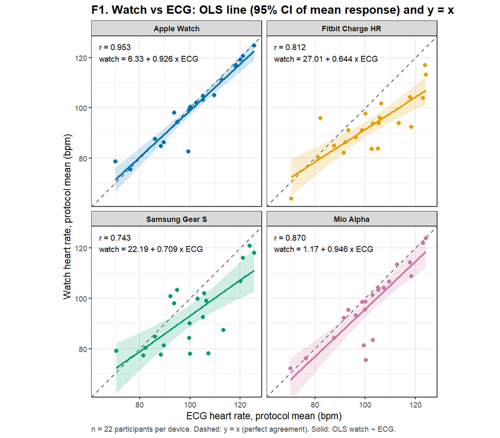

- Apple Watch의 r이 가장 높고(0.953), Samsung Gear S가 가장 낮다(0.743).
- **Samsung**: 과제의 Pearson r = **0.743**, Spearman ρ = **0.670**. 원문 0.67*은 ρ이며, 우리 ρ와 반올림 범위에서 같다 (HR06). 두 값은 서로 다른 통계량이므로 **Pearson 0.743을 0.67로 바꾸거나 둘을 '불일치'로 세지 않는다** (ISS-05).
- 22명뿐이라 CI가 넓다. Fitbit의 CI 0.59–0.92와 Mio의 0.71–0.95가 크게 겹치므로, r의 순서만으로 기기 간 차이를 주장할 수 없다. 기기 간 상관 차이 검정은 범위 밖이며 하지 않았다.

## 남은 질문

- 상관이 높다는 것은 "같은 값을 낸다"는 뜻이 아니다. F1에서 Fitbit 점들은 대부분 y = x 아래에 있다. 얼마나 아래인가는 HR03(기울기)과 HR04(오차)가 답한다.
- 참가자들의 평균 HR 범위(102 ± 14 bpm 수준)가 넓을수록 r은 커지기 쉽다. 평균 자료의 r을 운동 중 순간 정확도로 읽지 않는다.
- ISS-06: Samsung만 Spearman을 쓴 근거(정규성 판정 방법)는 미확인이다.

**MD 원문 보기 (docs/learning/HR02-paper.md)**

### HR03 · 시계 ~ ECG 단순 선형회귀

질문: ECG가 1 bpm 오를 때 시계는 평균 몇 bpm 오르는가? y = x에서 어디서 벗어나는가?

CONCEPT / 일반 통계 개념

# HR03 · CONCEPT — 최소제곱 단순 선형회귀: 절편, 기울기, 잔차, R², 구간

> 일반 통계 개념 페이지. 숫자는 모두 **🧪 가상 예제**. 실제 적용은 HR03-paper.

## 입력

(x, y) 짝 n개. 여기서는 x = ECG, y = 시계. "시계 ~ ECG" 회귀는 "**ECG가 주어졌을 때 시계가 평균적으로 얼마를 내놓는가**"를 묻는다.

## 이번 질문

시계 값이 기준값을 따라갈 때 **기울기**(비례 관계)와 **절편**(고정된 차이)은 얼마인가? 완벽한 시계라면 y = x, 즉 절편 0, 기울기 1이다.

## 방법과 이유

### 최소 공식

```
ŷ = b₀ + b₁·x
b₁ = Σ(x − x̄)(y − ȳ) / Σ(x − x̄)²      b₀ = ȳ − b₁·x̄
잔차 eᵢ = yᵢ − ŷᵢ,   s = √[ Σeᵢ² / (n − 2) ]
R² = 1 − Σeᵢ² / Σ(y − ȳ)²   (단순회귀에서는 R² = r²)
```

"최소제곱"은 잔차 제곱합을 가장 작게 만드는 직선을 고른다는 뜻이다.

### 🧪 가상 예제: HR02의 시계 B

x = 60, 80, 100, 120, 140 / y = 62, 78, 101, 119, 140

- b₁ = 3940 / 4000 = **0.985**, b₀ = 100 − 0.985 × 100 = **1.5**
- 적합값: 60.6, 80.3, 100.0, 119.7, 139.4
- 잔차: +1.4, −2.3, +1.0, −0.7, +0.6 (합 = 0)
- 잔차 제곱합 9.1 → s = √(9.1/3) = 1.74, R² = 1 − 9.1/3890 = **0.998**

### 잔차 ≠ 측정오차

- 측정오차 = 시계 − **기준값**: +2, −2, +1, −1, 0
- OLS 잔차 = 시계 − **회귀선 적합값**: +1.4, −2.3, +1.0, −0.7, +0.6

시계 C(= 0.5x + 50)는 OLS 잔차가 모두 0이고 R² = 1이다. 그런데 측정오차는 +20, +10, 0, −10, −20이다. **회귀선에 잘 맞는 것과 기준값에 맞는 것은 다르다.** 기울기 0.5가 "고강도에서 과소측정"을 알려 준다.

### 세 가지 구간을 섞지 않기

| 구간 | 질문 | 폭 |
| --- | --- | --- |
| 계수 95% CI | 기울기·절편이 얼마쯤인가 | 좁음 |
| 평균반응 95% CI | x가 이 값인 사람들의 **평균** 시계값 | 중간 (그림의 띠) |
| 개인 예측 95% 구간 | x가 이 값인 **새 한 사람**의 시계값 | 넓음 |

### 가정

선형성, 잔차의 독립, 등분산, (작은 n에서 구간을 위해) 잔차 정규성. 점검은 HR05.

### 대안이 답하는 질문

- "시계 값으로 ECG를 예측하려면?" → ECG ~ 시계 회귀(방향이 다르면 기울기도 다르다).
- "두 방법 모두 오차가 있다면?" → Deming 회귀, Passing–Bablok 같은 방법 비교 회귀.
- "차이가 평균 크기에 따라 변하나?" → Bland–Altman 그림에서 차이 ~ 평균 회귀 (HR04).

## 출력

절편·기울기와 각 95% CI, R², 잔차 SE, 회귀선과 y = x를 함께 그린 그림.

## 남은 질문

- R²가 높다고 이 회귀식이 **다른 사람에게 보정식으로 쓸 만하다**고 할 수 있나? 아니다. 같은 자료에 맞춘 적합도일 뿐, 새 자료에서 검증하지 않았다.
- 기울기 CI에 1이 들어가면 "기울기가 1이다"인가? 아니다. "1과 다르다는 근거가 부족하다"일 뿐이며, n이 작으면 CI가 넓다.

**MD 원문 보기 (docs/learning/HR03-concept.md)**

PAPER / 논문·실제 데이터 적용

# HR03 · PAPER — 시계 ~ ECG 단순 선형회귀

> 논문·실제 데이터 적용 페이지. 수치는 run `R1-20261025` `hr03_ols.csv`에서 채웠다. 일반 개념은 HR03-concept.

## 입력

기기별 22쌍. 모형 `lm(device_hr ~ ecg_hr)` (반응 = 시계, 설명 = ECG). 모형 객체는 `runs/R1-20261025/models/ols_models.rds`.

## 이번 질문

ECG가 1 bpm 오를 때 시계는 평균 몇 bpm 오르는가(기울기)? 완벽한 시계라면 절편 0, 기울기 1인데, 어디서 벗어나는가?

## 방법과 이유

- **[과제]의 회귀와 [원문]의 회귀는 다르다.**
  - 과제: 시계 ~ ECG OLS. "ECG 값에 따라 시계가 평균적으로 어떻게 읽히는가"를 본다.
  - 원문: "systematic bias was assessed using linear regression to determine whether mean difference and/or limits of agreement varied across average values" — Bland–Altman의 **차이 ~ 평균** 회귀다. Mio HR의 LoA 식(−0.44·avg + 52.69 등)이 여기서 나왔다. 원문은 시계 ~ ECG OLS를 보고하지 않았으므로 이 페이지의 결과는 **원문과 비교할 대상이 없다**.
- 계수 95% CI = `confint` (t 분포, 자유도 20). 그림의 띠는 평균반응 95% CI이고, 개인 예측구간(`hr03_ols_bands.csv`의 pred_lo/pred_hi)은 표로만 남겼다. 두 구간을 섞지 않는다.

## 출력

| 기기 | n | 절편 (bpm) | 절편 95% CI | 기울기 | 기울기 95% CI | R² | 잔차 SE (bpm) | 기울기 CI에 1 포함 |
| --- | --- | --- | --- | --- | --- | --- | --- | --- |
| Apple Watch | 22 | 6.33 | [-7.81, 20.46] | 0.926 | [0.788, 1.063] | 0.908 | 4.35 | 예 |
| Fitbit Charge HR | 22 | 27.01 | [4.79, 49.23] | 0.644 | [0.428, 0.860] | 0.659 | 6.88 | 아니오 |
| Samsung Gear S | 22 | 22.19 | [-8.09, 52.47] | 0.709 | [0.411, 1.007] | 0.551 | 9.57 | 예 |
| Mio Alpha | 22 | 1.17 | [-24.52, 26.86] | 0.946 | [0.696, 1.196] | 0.757 | 7.36 | 예 |

F1(산점도)의 실선이 이 회귀선이고, 점선이 y = x다.

- **Apple Watch**: 기울기 0.926 (95% CI 0.788–1.063), R² = 0.908. 기울기 CI에 1이, 절편 CI에 0이 들어가 y = x와 다르다는 근거가 약하다.
- **Fitbit Charge HR**: 기울기 0.644 (CI 0.428–0.860)로 **CI가 1을 포함하지 않는다**. ECG가 높은 사람일수록 시계가 더 많이 낮게 읽는 비례적 과소측정과 호환되는 모양이다. 절편 27.0은 기울기가 1보다 작은 것을 보상하는 값이며 단독으로 해석하지 않는다.
- **Samsung Gear S**: 기울기 0.709이고 CI 0.411–1.007가 넓다. 잔차 SE 9.6 bpm으로 네 기기 중 흩어짐이 가장 크다.
- **Mio Alpha**: 기울기 0.946로 1에 가깝지만, 선 전체가 y = x 아래에 있다(체계적 과소측정, HR04).
- R² = r²이므로 HR02의 상관과 같은 정보다. R²는 **이 22명에 대한 적합도**이며, 이 식을 다른 사람의 시계 값 보정에 써도 된다는 검증 성능이 아니다.

## 남은 질문

- 기울기 CI에 1이 들어간다고 "기울기가 1이다"라고 결론 내리지 않는다. n = 22에서는 CI가 넓다.
- ECG도 평균값이라 측정 잡음이 있다. x에 오차가 있으면 OLS 기울기는 1보다 작아지는 쪽으로 치우칠 수 있다(희석). 방법 비교 회귀(Deming 등)는 범위 밖이다.
- 원문의 차이 ~ 평균 회귀 세부(절대잔차 회귀 여부, 유의 기준)는 보고되지 않았고 재현하지 않았다 (ISS-10).

**MD 원문 보기 (docs/learning/HR03-paper.md)**

### HR04 · 측정오차와 Bland-Altman

질문: 시계는 ECG와 평균적으로, 그리고 사람마다 얼마나 다른가? 상관이 높아도 어긋날 수 있는가?

CONCEPT / 일반 통계 개념

# HR04 · CONCEPT — 측정오차: bias, MAE, RMSE, 분포, Bland–Altman

> 일반 통계 개념 페이지. 숫자는 모두 **🧪 가상 예제**. 실제 적용은 HR04-paper.

## 입력

짝 (시계, 기준) n개. 오차 eᵢ = 시계ᵢ − 기준ᵢ. **부호 규칙을 먼저 고정한다**: 음수 = 시계가 낮게 잼(과소측정).

## 이번 질문

"시계는 기준값과 **얼마나 같은가**?" 평균적으로 치우쳤는가(체계 오차), 사람마다 얼마나 흩어지는가(무작위 오차), 한 사람의 오차는 대략 어느 범위인가?

## 방법과 이유

### 최소 공식

```
bias = ē = Σeᵢ / n                     평균적 치우침
SD   = √[ Σ(eᵢ − ē)² / (n − 1) ]        사람 간 흩어짐
MAE  = Σ|eᵢ| / n                        부호를 뺀 평균 크기
RMSE = √( Σeᵢ² / n )  (≈ √(bias² + SD²))  치우침 + 흩어짐
bias의 95% CI = ē ± t(0.975, n−1) · SD/√n     "평균 오차"의 불확실성
고정 95% LoA  = ē ± 1.96 · SD                  "한 사람의 오차"가 놓일 범위
```

### 🧪 가상 예제: HR02의 시계 세 종류

| 시계 | 오차 e | bias | SD | MAE | RMSE | 95% LoA | r |
| --- | --- | --- | --- | --- | --- | --- | --- |
| A (x−10) | −10, −10, −10, −10, −10 | −10 | 0 | 10 | 10 | −10 ~ −10 | 1 |
| B | +2, −2, +1, −1, 0 | 0 | 1.58 | 1.2 | 1.41 | −3.1 ~ +3.1 | 0.999 |
| C (0.5x+50) | +20, +10, 0, −10, −20 | 0 | 15.8 | 12 | 14.1 | −31 ~ +31 | 1 |

- A: r = 1인데 모든 사람에게 10 bpm 낮다 → **체계 오차**.
- C: r = 1, bias = 0인데 개인 오차가 ±31 → bias만 보고 "정확"이라 할 수 없다.
- B만 상관·bias·흩어짐 모두 좋다.

### 두 구간을 섞지 않기

B에서 bias 95% CI = 0 ± 2.776 × 1.58/√5 = **−1.96 ~ +1.96**, LoA = **−3.1 ~ +3.1**. CI는 n이 커지면 좁아진다(평균을 더 잘 앎). LoA는 n이 커져도 좁아지지 않는다(사람 간 흩어짐 자체).

### Bland–Altman 그림

x축 = (시계 + 기준)/2, y축 = 시계 − 기준. 수평선 3개: bias, bias ± 1.96 SD. 🧪 시계 C: 평균 70, 85, 100, 115, 130에서 차이 +20, +10, 0, −10, −20 → 오른쪽 아래로 기운 띠. **차이가 크기에 따라 변하면(비례 오차)** 고정 LoA 한 쌍은 맞지 않는다. 이때 "차이 ~ 평균" 회귀로 bias와 LoA를 평균의 함수로 쓰는 방법(가변 LoA)이 있다. 고정 LoA와 가변 LoA는 **추정 대상이 다르다**.

### 분포를 보는 이유

LoA의 ±1.96 SD는 오차가 대략 정규일 때 "95%"라는 뜻을 갖는다. 한쪽으로 긴 꼬리가 있으면 히스토그램·중앙값·최소/최대를 함께 본다.

### 가정과 대안 질문

- 사람끼리 독립, 오차의 평균·SD가 측정 범위 전체에서 비슷함.
- "얼마나 틀려도 괜찮은가?"는 통계가 정하지 않는다. 임상·사용 목적의 허용 범위를 **미리** 정해야 한다.
- "두 방법이 서로 바꿔 써도 되나?"는 LoA를 허용 범위와 비교하는 판단이다.

## 출력

기기별 bias(+95% CI), SD, MAE, RMSE, 고정 LoA, 오차 히스토그램, Bland–Altman 그림.

## 남은 질문

- 평균 HR 하나의 오차가 작아도, 운동 중 순간 HR의 오차는 클 수 있다(평균이 상쇄함).
- LoA 자체도 표본 추정치라 불확실성이 있다(LoA의 CI). 이번 범위에서는 계산하지 않았다.

**MD 원문 보기 (docs/learning/HR04-concept.md)**

PAPER / 논문·실제 데이터 적용

# HR04 · PAPER — 측정오차(시계 − ECG)의 평균과 분포, Bland–Altman

> 논문·실제 데이터 적용 페이지. 수치는 run `R1-20261025` `hr04_error.csv`에서 채웠다. 일반 개념은 HR04-concept.

## 입력

기기별 22개 오차 e = 시계 − ECG (bpm). 음수 = 시계가 낮게 잼.

## 이번 질문

시계는 ECG와 평균적으로 얼마나 다른가(bias)? 사람마다 얼마나 흩어지는가(SD, LoA)? **상관이 높은 기기도 값이 어긋날 수 있는가?** (6주차 검증 과제)

## 방법과 이유

- [과제] 오차 = 시계 − 기준. [원문]도 같은 방향이다(Table 1 "Mean difference"가 음수이고 "underestimated"로 서술).
- bias 95% CI = t 분포 (자유도 21). 고정 95% LoA = bias ± 1.96 × SD (SD는 n − 1). 둘은 다른 질문에 답한다: CI는 **평균 오차**의 불확실성, LoA는 **한 사람의 오차**가 놓일 범위다.
- `bias/ECG 평균 (%)`는 **부호가 있는** 백분율이다(음수 = 과소측정). 계획서는 |bias|라고 적었으나 코드는 부호를 유지했다. 크기는 같다 (ISS-20).
- [원문] Mio HR은 "systematically biased"로 판단해 LoA를 평균값의 함수(Upper = −0.44·avg + 52.69, Lower = 0.4·avg − 61.2)로 보고했다. 이 **가변 LoA**는 이 페이지의 **고정 LoA와 추정 대상이 다르므로 같은 결과로 비교하지 않는다** (HR06, ISS-10).

## 출력

| 기기 | n | 시계 평균 ± SD | ECG 평균 ± SD | 평균오차(bias) | bias 95% CI (t) | 오차 SD | MAE | RMSE | bias/ECG 평균 (%) | 고정 95% LoA | 음수 오차 수 |
| --- | --- | --- | --- | --- | --- | --- | --- | --- | --- | --- | --- |
| Apple Watch | 22 | 100.7 ± 14.0 | 102.0 ± 14.4 | -1.26 | [-3.20, 0.68] | 4.38 | 2.53 | 4.46 | -1.2 | [-9.84, 7.32] | 18/22 |
| Fitbit Charge HR | 22 | 92.7 ± 11.5 | 102.0 ± 14.5 | -9.32 | [-13.08, -5.56] | 8.48 | 10.55 | 12.47 | -9.1 | [-25.94, 7.30] | 21/22 |
| Samsung Gear S | 22 | 93.4 ± 13.9 | 100.5 ± 14.6 | -7.05 | [-11.60, -2.50] | 10.26 | 9.74 | 12.25 | -7.0 | [-27.15, 13.06] | 18/22 |
| Mio Alpha | 22 | 97.7 ± 14.6 | 102.0 ± 13.4 | -4.34 | [-7.54, -1.14] | 7.22 | 4.81 | 8.28 | -4.3 | [-18.49, 9.80] | 18/22 |

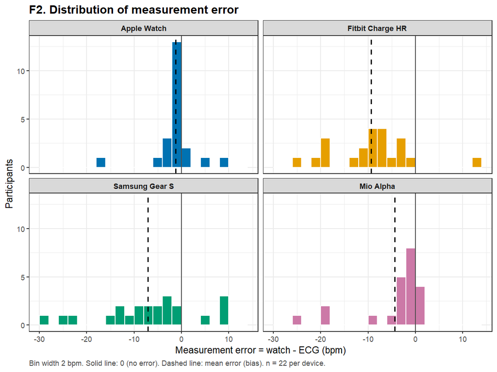

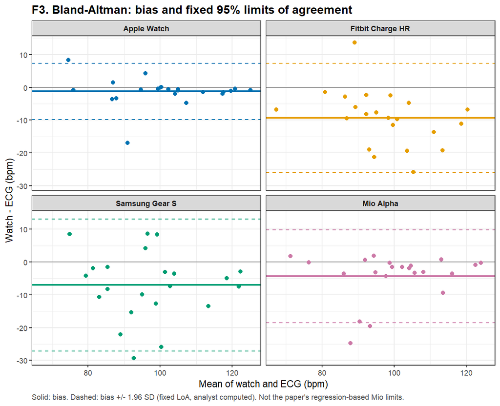

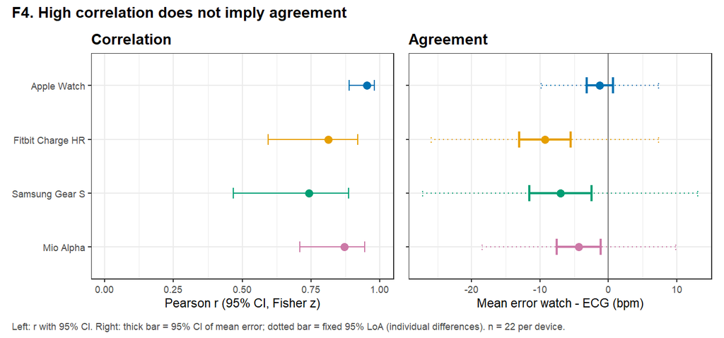

### 상관이 높아도 일치하지 않는다 (검증 과제)

- **Fitbit Charge HR**: r = 0.81로 '강한' 상관(원문 기준 r ≥ 0.7)이지만, 평균오차 -9.3 bpm (95% CI -13.1 ~ -5.6)이다. 22명 중 21명에서 시계가 낮게 읽었다.
- **Mio Alpha**는 r = 0.87로 Fitbit보다 상관이 높지만 bias -4.3 bpm으로 0과 구별되고, LoA 하한이 -18.5 bpm이다. F2에서 대부분은 0 근처에 몰려 있지만 몇 사람이 −15 ~ −25 bpm으로 크게 낮다. 평균과 LoA는 이 소수의 꼬리에 끌린다(중앙값 -1.7).
- **Apple Watch**만 bias -1.3 bpm의 95% CI(-3.2 ~ 0.7)가 0을 포함한다. 그래도 개인 오차는 LoA -9.8 ~ 7.3 bpm 범위다.
- **Samsung Gear S**는 LoA 폭이 가장 넓다(-27.2 ~ 13.1). 원문도 Samsung을 HR 변동이 가장 큰 기기로 보고했다.
- 네 기기 모두 평균 오차가 음수다. 원문의 "All devices underestimated" 및 "1–9%"와 같은 방향·크기다(bias/ECG 평균 = Apple -1.2% ~ Fitbit -9.1%, 음수 = 과소측정).

F4가 이 대비를 한눈에 보여 준다. 왼쪽 상관 순서와 오른쪽 오차 크기의 순서가 같지 않다.

## 남은 질문

- 몇 bpm까지 허용할지는 사용 목적(운동 강도 처방, 에너지 소비 추정)이 정해야 하며, 이 분석은 허용 기준을 정하지 않았다. 따라서 "임상적으로 교환 가능하다/불가능하다"는 판정을 내리지 않는다.
- 이 오차는 **약 58분 평균 HR**의 오차다. 순간 HR이나 활동별 오차는 더 클 수 있으나 공개 자료로는 볼 수 없다 (ISS-03).
- 오차 분포가 꼬리를 가지면(Mio, Apple) ±1.96 SD의 '95%' 해석은 근사다. LoA의 CI는 계산하지 않았다.

**MD 원문 보기 (docs/learning/HR04-paper.md)**

### HR05 · 잔차 진단과 한 명씩 제외

질문: 회귀 가정이 크게 어긋나는가? 한 사람이 결론을 좌우하는가?

CONCEPT / 일반 통계 개념

# HR05 · CONCEPT — 잔차 진단, Q–Q, 영향점, 민감도의 의미

> 일반 통계 개념 페이지. 숫자는 모두 **🧪 가상 예제**. 실제 적용은 HR05-paper.

## 입력

HR03에서 적합한 OLS 모형과 잔차, HR04의 오차 요약.

## 이번 질문

"결과가 회귀 가정을 크게 어기지 않는가? 한두 사람이 결론을 좌우하는가?" 진단은 **결과를 고르려는** 것이 아니라 **결과를 얼마나 믿을지** 알려는 것이다.

## 방법과 이유

### 잔차 대 적합값 그림

가로 = 적합값, 세로 = 잔차. 0 주위에 고르게 퍼지면 좋다.

- 곡선 모양 → 직선 관계가 아님
- 깔때기 모양 → 등분산 위반
- 홀로 멀리 떨어진 점 → 이상치 후보

### 표준화 잔차와 Q–Q 그림

표준화 잔차 = 잔차 / (s·√(1 − hᵢ)). 대략 정규라면 |값| > 2는 20명 중 1명 정도로 드물다. Q–Q 그림: 표준화 잔차를 크기순으로 놓고 정규분포 분위수와 짝지어 그린다. 직선 위에 있으면 정규에 가깝다. n = 22 정도에서는 우연히도 꼬리가 휘기 쉬워 **강한 결론을 내리지 않는다**.

### 레버리지와 Cook's distance

```
레버리지 hᵢ = 1/n + (xᵢ − x̄)² / Σ(x − x̄)²       x가 평균에서 멀수록 큼
Cook's Dᵢ = (eᵢ² / (p·s²)) · hᵢ / (1 − hᵢ)²      p = 계수 수(2)
```

Cook's D는 "i를 빼면 적합선이 얼마나 움직이나"를 한 숫자로 요약한다. 4/n 같은 기준선은 **경험칙**이지 검정이 아니다.

- 잔차가 커도 x가 가운데면(레버리지 작음) 선을 많이 못 움직인다.
- 잔차가 작아도 x가 끝에 있으면(레버리지 큼) 선을 끌어당길 수 있다.

### 한 명씩 제외(leave-one-out) 민감도

n번 다시 계산하며 매번 한 명을 뺀다. 🧪 시계 B 오차 +2, −2, +1, −1, 0에서 한 명씩 빼면 bias = −0.5, +0.5, −0.25, +0.25, 0 → **범위 −0.5 ~ +0.5**.

- 이 범위는 **신뢰구간이 아니다**(표본추출 확률 해석이 없음).
- **교차검증도 아니다**(새 사람에 대한 예측 성능을 재지 않음).
- "특정 한 사람이 결론을 뒤집는가"만 보여 준다.

### 영향점을 지우지 않는 이유

측정 비교에서는 크게 틀린 사람이 바로 **시계가 실패한 사례**일 수 있다. 근거(측정 실패 기록 등) 없이 지우면 정확도를 부풀린다. 주 분석은 전원 유지, 제외는 별도 시나리오로만 보인다.

## 출력

잔차 대 적합값, Q–Q, Cook's D 그림, 영향점 표, 한 명씩 제외 범위 표.

## 남은 질문

- 진단 결과 가정이 의심되면? → 다른 모형(로버스트 회귀 등)은 **다른 추정 대상**일 수 있어 우열 비교가 아니라 보완 질문으로 다룬다.
- 영향이 큰 사람의 원인(움직임, 착용 위치, 피부)은 평균 자료만으로 알 수 없다.

**MD 원문 보기 (docs/learning/HR05-concept.md)**

PAPER / 논문·실제 데이터 적용

# HR05 · PAPER — 잔차 진단, 영향점, 한 명씩 제외 민감도

> 논문·실제 데이터 적용 페이지. 수치는 run `R1-20261025` `hr05_*.csv`에서 채웠다. 일반 개념은 HR05-concept.

## 입력

HR03의 기기별 OLS 모형 4개, HR04의 오차.

## 이번 질문

기기별 OLS가 가정을 크게 어기는가? 특정 한 사람이 r·기울기·bias·LoA를 좌우하는가?

## 방법과 이유

- [원문] 잔차 진단이나 영향점 분석을 보고하지 않았다. 이 단계는 **과제의 보조 진단**이며 원문 재현이 아니다.
- 잔차 대 적합값, 표준화 잔차 Q–Q, Cook's distance (참조선 4/n = 0.18은 경험칙).
- 한 명씩 제외: 기기마다 22번, 매번 1명을 빼고 21명으로 다시 계산. **주 분석(22명 전원)은 그대로 두고** 별도 시나리오로만 보인다. 이 범위는 CI가 아니고, 새 사람에 대한 예측을 재는 교차검증도 아니다.

## 출력

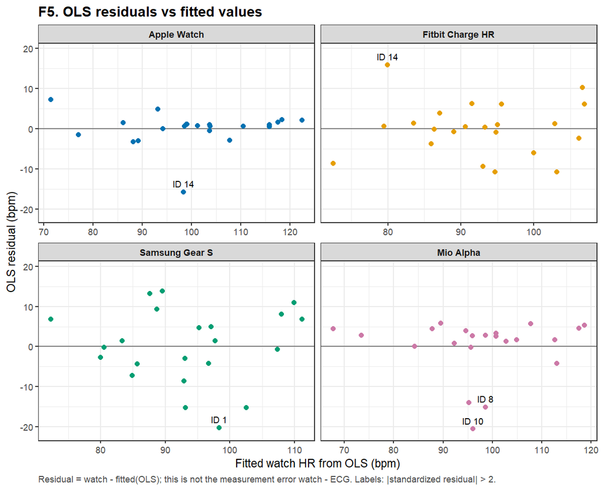

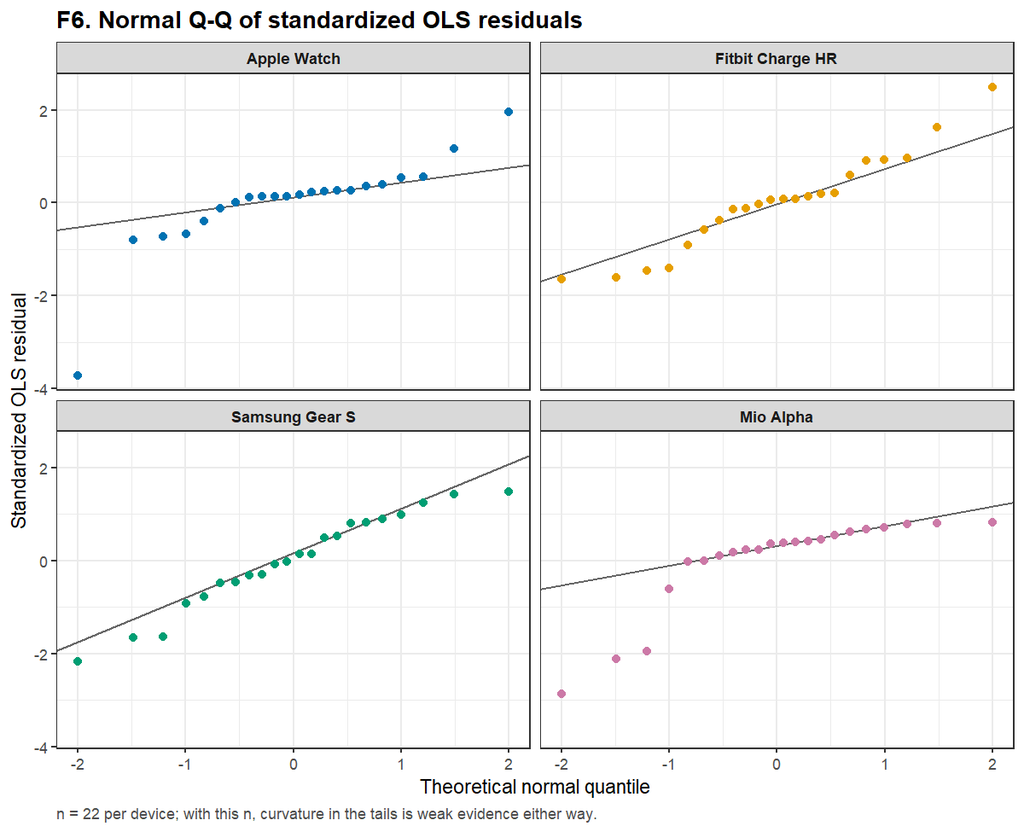

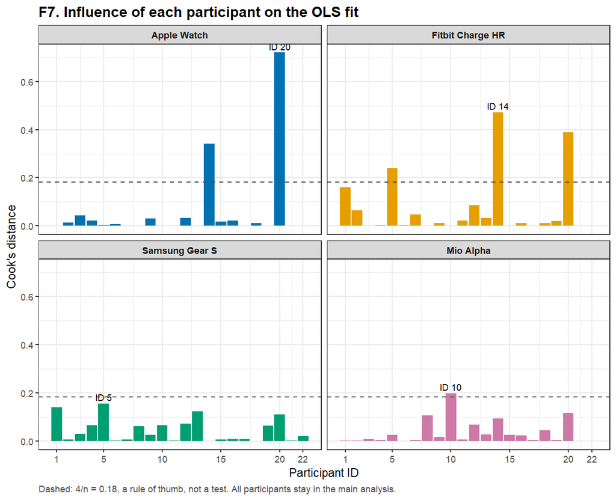

Cook's D > 4/n 또는 |표준화 잔차| > 2인 경우:

| 기기 | ID | 시계 HR | ECG HR | 측정오차 | OLS 잔차 | 표준화 잔차 | 레버리지 | Cook's D |
| --- | --- | --- | --- | --- | --- | --- | --- | --- |
| Apple Watch | 20 | 78.67 | 70.36 | 8.31 | 7.22 | 1.95 | 0.275 | 0.720 |
| Apple Watch | 14 | 82.57 | 99.46 | -16.89 | -15.82 | -3.73 | 0.047 | 0.342 |
| Fitbit Charge HR | 14 | 95.86 | 82.27 | 13.59 | 15.89 | 2.48 | 0.133 | 0.472 |
| Fitbit Charge HR | 20 | 63.88 | 70.65 | -6.77 | -8.61 | -1.46 | 0.267 | 0.389 |
| Fitbit Charge HR | 5 | 117.01 | 123.78 | -6.77 | 10.31 | 1.63 | 0.153 | 0.239 |
| Samsung Gear S | 1 | 78.07 | 107.37 | -29.30 | -20.25 | -2.18 | 0.056 | 0.141 |
| Mio Alpha | 10 | 75.49 | 100.29 | -24.80 | -20.55 | -2.86 | 0.046 | 0.198 |
| Mio Alpha | 8 | 83.49 | 103.02 | -19.53 | -15.13 | -2.11 | 0.046 | 0.106 |

한 명씩 제외한 결과의 범위:

| 기기 | 지표 | 전체 22명 | 한 명씩 제외한 21명 결과의 범위 | 가장 크게 바꾼 제외 ID |
| --- | --- | --- | --- | --- |
| Apple Watch | Pearson r | 0.953 | 0.944 ~ 0.985 | 14 |
| Apple Watch | 기울기 | 0.926 | 0.911 ~ 0.998 | 20 |
| Apple Watch | bias | -1.26 | -1.72 ~ -0.52 | 14 |
| Apple Watch | LoA 하한 | -9.84 | -10.09 ~ -5.81 | 14 |
| Apple Watch | LoA 상한 | 7.32 | 4.78 ~ 7.58 | 14 |
| Fitbit Charge HR | Pearson r | 0.812 | 0.747 ~ 0.874 | 20 |
| Fitbit Charge HR | 기울기 | 0.644 | 0.561 ~ 0.725 | 20 |
| Fitbit Charge HR | bias | -9.32 | -10.41 ~ -8.53 | 14 |
| Fitbit Charge HR | LoA 하한 | -25.94 | -26.44 ~ -23.86 | 1 |
| Fitbit Charge HR | LoA 상한 | 7.30 | 3.17 ~ 7.81 | 14 |
| Samsung Gear S | Pearson r | 0.743 | 0.697 ~ 0.797 | 1 |
| Samsung Gear S | 기울기 | 0.709 | 0.641 ~ 0.770 | 5 |
| Samsung Gear S | bias | -7.05 | -7.79 ~ -5.99 | 1 |
| Samsung Gear S | LoA 하한 | -27.15 | -27.76 ~ -24.01 | 1 |
| Samsung Gear S | LoA 상한 | 13.06 | 11.57 ~ 13.67 | 10 |
| Mio Alpha | Pearson r | 0.870 | 0.848 ~ 0.915 | 10 |
| Mio Alpha | 기울기 | 0.946 | 0.908 ~ 1.000 | 20 |
| Mio Alpha | bias | -4.34 | -4.64 ~ -3.37 | 10 |
| Mio Alpha | LoA 하한 | -18.49 | -18.92 ~ -14.58 | 10 |
| Mio Alpha | LoA 상한 | 9.80 | 7.85 ~ 10.22 | 10 |

### 읽는 법

- **Apple Watch ID 20**은 ECG가 가장 낮은 사람(레버리지 큼)이라 Cook's D가 가장 크다. 빼면 기울기가 0.926에서 0.998까지 움직인다. **Apple ID 14**는 오차가 큰 사람(시계 82.57 vs ECG 99.46)으로, 빼면 LoA 하한이 -9.8에서 -5.8로 좁아진다. 그래도 Apple의 r은 어떤 한 명을 빼도 0.944 이상이다.
- **Fitbit ID 14**는 시계가 ECG보다 **높게** 읽은 드문 사람이다. 빼면 LoA 상한이 7.3에서 3.2로 줄어든다. 그래도 Fitbit bias는 -10.4 ~ -8.5 범위에 머문다.
- **Mio ID 10**(시계 75.49 vs ECG 100.29)이 Mio의 큰 음의 꼬리를 대표한다. 빼면 LoA 하한이 -18.5에서 -14.6로 바뀐다.
- Q–Q(F6)에서 Apple·Mio의 아래쪽 꼬리가 직선에서 벗어난다. n = 22에서는 결정적 근거가 아니지만, HR04의 LoA를 '정확히 95%'로 읽지 말아야 할 이유다.
- **결론**: 어떤 한 명을 빼도 bias의 부호(음수)와 기기들의 대략적인 순서는 바뀌지 않는다. LoA 폭은 한두 사람에 민감하다. 영향이 큰 사람은 시계가 실제로 크게 틀린 사례일 수 있으므로 **주 분석에서 지우지 않았다** (ISS-14).

## 남은 질문

- 왜 이 사람들에서 크게 틀렸는가(움직임, 착용 위치, 피부 유형)는 평균 자료로 알 수 없다. 원문은 피부 유형 하위집단 상관을 보고했지만 범위 밖이다.
- 등분산 가정은 F5에서 크게 어긋나 보이지 않지만 검정하지 않았다.

**MD 원문 보기 (docs/learning/HR05-paper.md)**

### HR06 · 원문 Table 1 대조

질문: 같은 자료·같은 정의로 원문 Table 1의 HR 값이 나오는가?

CONCEPT / 일반 통계 개념

# HR06 · CONCEPT — 같은 정의의 비교, 반올림, 수치 일치의 한계

> 일반 통계 개념 페이지. 숫자는 모두 **🧪 가상 예제**. 실제 적용은 HR06-paper.

## 입력

논문에 인쇄된 값(보통 반올림됨)과, 공개 자료로 다시 계산한 값.

## 이번 질문

"내가 계산한 값이 논문 값과 같은가?"보다 먼저 "**둘이 같은 것을 잰 값인가?**"를 묻는다.

## 방법과 이유

### 비교 가능성 점검표

1. 같은 자료 (같은 버전, 같은 표본, 같은 결측 처리)
2. 같은 추정 대상 (Pearson r ↔ Pearson r. Spearman ρ와 비교하지 않음)
3. 같은 단위와 집계 수준 (참가자 평균 ↔ 참가자 평균)
4. 같은 보고 척도 (고정 LoA ↔ 고정 LoA. 회귀식 LoA와 비교하지 않음)

하나라도 다르면 "불일치"가 아니라 "**비교 불가**"다.

### 허용오차는 결과를 보기 전에

소수 첫째 자리로 보고된 값 102.0은 실제로 101.95 ~ 102.05 사이 어딘가다. 그래서

- 소수 첫째 자리 값: |차이| ≤ 0.05
- 소수 둘째 자리 값: |차이| ≤ 0.005

결과를 본 뒤 허용오차를 넓히면, 무엇이든 "일치"로 만들 수 있다. **정한 시점을 기록**한다.

### 🧪 가상 예제: 반올림 순서가 결과를 바꾼다

시계 평균 93.44, 기준 평균 100.49.

- 차이를 먼저 계산 → −7.05 → 소수 첫째 자리 반올림: **−7.1**(0.5에서 0에서 멀어지게) 또는 **−7.0**(짝수 쪽으로, 부동소수 표현에 따라)
- 먼저 반올림 → 93.4 − 100.5 = **−7.1**

r = 0.9529를 0.95로 반올림한 뒤 CI를 계산하면 [0.881, 0.979] → "0.88 to 0.98", 반올림 전 값으로 계산하면 [0.888, 0.981] → "0.89 to 0.98". 하한이 0.01 달라진다.

### 일치가 말해 주는 것과 못 하는 것

| 관찰 | 말할 수 있음 | 말할 수 없음 |
| --- | --- | --- |
| 반올림 범위 안에서 일치 | 같은 자료·정의로 그 숫자가 나올 수 있다 | 저자가 정확히 이 방법으로 계산했다 |
| 반올림된 중간값으로 계산하면 일치 | 그런 계산 경로와 호환된다 | 저자가 그렇게 했다 (다른 경로도 같은 값을 낼 수 있음) |
| 두 경로가 같은 값 | — | 어느 경로인지 (**식별 불가**) |
| 일치하지 않음 | 차이가 있다, 원인 조사 필요 | 논문이 틀렸다 (자료 버전·정의·내 오류 먼저 확인) |

### 사후 탐색의 표시

결과를 본 뒤 "이렇게 계산하면 맞을까?" 하고 후보를 만들면 그것은 **탐색적**(post-result)이다. 후보 수를 미리 정하고, 맞지 않은 후보도 모두 남긴다.

## 출력

항목별 원문 값 / 내 값 / 차이 / 사전 허용오차 / 판정(반올림 일치·불일치·비교 불가), 그리고 별도로 표시한 탐색적 후보 표.

## 남은 질문

- 원문이 계산 방법(CI 공식, 정규성 판정 기준)을 쓰지 않으면, 수치 일치만으로는 미확인으로 남는다.
- 수치가 다 맞아도 "그 분석이 질문에 적절한가"는 별개의 검토다 (HR07).

**MD 원문 보기 (docs/learning/HR06-concept.md)**

PAPER / 논문·실제 데이터 적용

# HR06 · PAPER — 원문 Table 1과의 비교

> 논문·실제 데이터 적용 페이지. 수치는 run `R1-20261025` `hr06_paper_comparison.csv`와 탐색적 run `R2-20261025` `hr06_rounding_candidates.csv`에서 채웠다. 일반 개념은 HR06-concept.

## 입력

- [원문] Table 1의 Heart rate 블록. PDF 5쪽에서 손으로 옮겨 `analysis/config/paper_table1_hr.csv`에 두었다(52개 셀). 별도 문맥 검토자가 PDF와 대조해 일치를 확인했다.
- 우리 값: HR02(상관), HR04(평균·SD·bias·LoA).

## 이번 질문

같은 공개 자료와 같은 정의로 계산하면 원문 Table 1의 HR 숫자가 나오는가? 다르면 왜 다른가?

## 방법과 이유

- **허용오차는 결과를 보기 전에** `plan_R1-20261025.json`에 고정했다(2026-10-25 16:48 KST). 보고 자릿수의 반 단위: 소수 첫째 자리 값은 ±0.05, 둘째 자리 값은 ±0.005, N은 정확히 일치.
- **같은 정의끼리만** 비교한다.
  - Samsung r/ρ는 원문이 Spearman이므로 우리 Spearman ρ와 비교하고, Pearson r은 따로 '비교 불가'로 둔다.
  - Mio LoA는 원문이 회귀식이므로 '비교 불가'다.
  - ICC는 범위 밖이라 계산하지 않았다.
- r의 CI 계산법은 원문에 없다 (ISS-07). Fisher z를 기본으로 가정했다 [분석자].

## 출력

### 사전 규칙에 따른 비교 (R1)

| 기기 | 항목 | 통계량 | 원문 표기 | 우리 값 | 차이 | 허용오차 | 판정 |
| --- | --- | --- | --- | --- | --- | --- | --- |
| Apple Watch | N | same definition | 22 | 22 | 0.0 | 0 | 반올림 일치 |
| Fitbit Charge HR | N | same definition | 22 | 22 | 0.0 | 0 | 반올림 일치 |
| Samsung Gear S | N | same definition | 22 | 22 | 0.0 | 0 | 반올림 일치 |
| Mio Alpha | N | same definition | 22 | 22 | 0.0 | 0 | 반올림 일치 |
| Apple Watch | 시계 평균 | same definition | 100.7 ±14.0 | 100.70 | 0.003 | 0.05 | 반올림 일치 |
| Fitbit Charge HR | 시계 평균 | same definition | 92.7 ± 11.5 | 92.66 | -0.043 | 0.05 | 반올림 일치 |
| Samsung Gear S | 시계 평균 | same definition | 93.4 ± 13.9 | 93.44 | 0.043 | 0.05 | 반올림 일치 |
| Mio Alpha | 시계 평균 | same definition | 97.7 ± 14.6 | 97.65 | -0.048 | 0.05 | 반올림 일치 |
| Apple Watch | 시계 SD | same definition | 100.7 ±14.0 | 13.99 | -0.007 | 0.05 | 반올림 일치 |
| Fitbit Charge HR | 시계 SD | same definition | 92.7 ± 11.5 | 11.51 | 0.012 | 0.05 | 반올림 일치 |
| Samsung Gear S | 시계 SD | same definition | 93.4 ± 13.9 | 13.94 | 0.040 | 0.05 | 반올림 일치 |
| Mio Alpha | 시계 SD | same definition | 97.7 ± 14.6 | 14.57 | -0.027 | 0.05 | 반올림 일치 |
| Apple Watch | ECG 평균 | same definition | 102.0 ± 14.4 | 101.96 | -0.037 | 0.05 | 반올림 일치 |
| Fitbit Charge HR | ECG 평균 | same definition | 102.0 ± 14.5 | 101.97 | -0.025 | 0.05 | 반올림 일치 |
| Samsung Gear S | ECG 평균 | same definition | 100.5 ± 14.6 | 100.49 | -0.009 | 0.05 | 반올림 일치 |
| Mio Alpha | ECG 평균 | same definition | 102.0 ± 13.4 | 101.99 | -0.007 | 0.05 | 반올림 일치 |
| Apple Watch | ECG SD | same definition | 102.0 ± 14.4 | 14.41 | 0.006 | 0.05 | 반올림 일치 |
| Fitbit Charge HR | ECG SD | same definition | 102.0 ± 14.5 | 14.52 | 0.021 | 0.05 | 반올림 일치 |
| Samsung Gear S | ECG SD | same definition | 100.5 ± 14.6 | 14.60 | -0.001 | 0.05 | 반올림 일치 |
| Mio Alpha | ECG SD | same definition | 102.0 ± 13.4 | 13.41 | 0.006 | 0.05 | 반올림 일치 |
| Apple Watch | r/ρ | Pearson r (CI: Fisher z) | 0.95 (0.88 to 0.98) | 0.953 | 0.0029 | 0.005 | 반올림 일치 |
| Fitbit Charge HR | r/ρ | Pearson r (CI: Fisher z) | 0.81 (0.59 to 0.92) | 0.812 | 0.0020 | 0.005 | 반올림 일치 |
| Samsung Gear S | r/ρ | Spearman rho (CI: Fisher z, SE=1/sqrt(n-3)) | 0.67* (0.35 to 0.85) | 0.670 | 0.0002 | 0.005 | 반올림 일치 |
| Mio Alpha | r/ρ | Pearson r (CI: Fisher z) | 0.87 (0.71 to 0.94) | 0.870 | 0.0002 | 0.005 | 반올림 일치 |
| Apple Watch | r/ρ CI 하한 | Pearson r (CI: Fisher z) | 0.95 (0.88 to 0.98) | 0.888 | 0.0081 | 0.005 | 불일치 |
| Fitbit Charge HR | r/ρ CI 하한 | Pearson r (CI: Fisher z) | 0.81 (0.59 to 0.92) | 0.594 | 0.0037 | 0.005 | 반올림 일치 |
| Samsung Gear S | r/ρ CI 하한 | Spearman rho (CI: Fisher z, SE=1/sqrt(n-3)) | 0.67* (0.35 to 0.85) | 0.347 | -0.0034 | 0.005 | 반올림 일치 |
| Mio Alpha | r/ρ CI 하한 | Pearson r (CI: Fisher z) | 0.87 (0.71 to 0.94) | 0.709 | -0.0015 | 0.005 | 반올림 일치 |
| Apple Watch | r/ρ CI 상한 | Pearson r (CI: Fisher z) | 0.95 (0.88 to 0.98) | 0.981 | 0.0006 | 0.005 | 반올림 일치 |
| Fitbit Charge HR | r/ρ CI 상한 | Pearson r (CI: Fisher z) | 0.81 (0.59 to 0.92) | 0.919 | -0.0010 | 0.005 | 반올림 일치 |
| Samsung Gear S | r/ρ CI 상한 | Spearman rho (CI: Fisher z, SE=1/sqrt(n-3)) | 0.67* (0.35 to 0.85) | 0.851 | 0.0013 | 0.005 | 반올림 일치 |
| Mio Alpha | r/ρ CI 상한 | Pearson r (CI: Fisher z) | 0.87 (0.71 to 0.94) | 0.945 | 0.0051 | 0.005 | 불일치 |
| Apple Watch | 평균차 | same definition | -1.3 ± 4.4 | -1.26 | 0.040 | 0.05 | 반올림 일치 |
| Fitbit Charge HR | 평균차 | same definition | -9.3 ± 8.5 | -9.32 | -0.018 | 0.05 | 반올림 일치 |
| Samsung Gear S | 평균차 | same definition | -7.1 ± 10.3 | -7.05 | 0.052 | 0.05 | 불일치 |
| Mio Alpha | 평균차 | same definition | -4.3 ± 7.2 | -4.34 | -0.040 | 0.05 | 반올림 일치 |
| Apple Watch | 평균차 SD | same definition | -1.3 ± 4.4 | 4.38 | -0.024 | 0.05 | 반올림 일치 |
| Fitbit Charge HR | 평균차 SD | same definition | -9.3 ± 8.5 | 8.48 | -0.021 | 0.05 | 반올림 일치 |
| Samsung Gear S | 평균차 SD | same definition | -7.1 ± 10.3 | 10.26 | -0.043 | 0.05 | 반올림 일치 |
| Mio Alpha | 평균차 SD | same definition | -4.3 ± 7.2 | 7.22 | 0.017 | 0.05 | 반올림 일치 |
| Apple Watch | LoA 상한 | fixed LoA = bias +/- 1.96 SD | 7.3 | 7.32 | 0.016 | 0.05 | 반올림 일치 |
| Fitbit Charge HR | LoA 상한 | fixed LoA = bias +/- 1.96 SD | 7.4 | 7.30 | -0.099 | 0.05 | 불일치 |
| Samsung Gear S | LoA 상한 | fixed LoA = bias +/- 1.96 SD | 13.1 | 13.06 | -0.044 | 0.05 | 반올림 일치 |
| Mio Alpha | LoA 상한 | fixed LoA = bias +/- 1.96 SD | -0.44.avg + 52.69† | 9.80 | — | — | 비교 불가 |
| Apple Watch | LoA 하한 | fixed LoA = bias +/- 1.96 SD | -9.9 | -9.84 | 0.063 | 0.05 | 불일치 |
| Fitbit Charge HR | LoA 하한 | fixed LoA = bias +/- 1.96 SD | -26.0 | -25.94 | 0.064 | 0.05 | 불일치 |
| Samsung Gear S | LoA 하한 | fixed LoA = bias +/- 1.96 SD | -27.3 | -27.15 | 0.148 | 0.05 | 불일치 |
| Mio Alpha | LoA 하한 | fixed LoA = bias +/- 1.96 SD | 0.4.avg—61.2† | -18.49 | — | — | 비교 불가 |
| Apple Watch | ICC | ICC (not computed) | 0.98 (0.94 to 0.99) | — | — | — | 비교 불가 |
| Fitbit Charge HR | ICC | ICC (not computed) | 0.78 (-0.02 to 0.93) | — | — | — | 비교 불가 |
| Samsung Gear S | ICC | ICC (not computed) | 0.80 (0.40 to 0.93) | — | — | — | 비교 불가 |
| Mio Alpha | ICC | ICC (not computed) | 0.91 (0.72 to 0.97) | — | — | — | 비교 불가 |
| Samsung Gear S | Pearson r (Samsung) | Pearson r (CI: Fisher z) | 0.67* (Spearman) | 0.743 | — | — | 비교 불가 |

요약: 비교 가능한 값 중 **39개 반올림 일치, 7개 불일치**이고, 비교 불가가 7개다. 이 판정은 사전 규칙대로 남기고, 아래 탐색 결과로 바꾸지 않는다.

- 표본수, 시계·ECG 평균과 SD, 4기기의 r/ρ 점추정, bias의 SD는 모두 일치한다. 공개 자료와 원문 Table 1이 **같은 22명 × 4기기 자료**라는 강한 정황이다.
- 불일치 7개는 모두 **다른 값에서 파생된 값**이다(r의 CI 경계, bias, LoA). 원본 요약(평균·SD·r)은 맞는다.

### 탐색적: 반올림된 중간값으로 계산했다면? (R2, post-result)

R1 결과를 **본 뒤** 불일치 패턴을 보고 만든 후보 4개다(`plan_R2-20261025.json`, 후보 수 고정, 추가 탐색 없음). 근거 유형은 **reproduction_candidate**다.

| 후보 | 기기 | 항목 | 계산 | 후보 값 | 원문 값 | 판정 |
| --- | --- | --- | --- | --- | --- | --- |
| C1 | Apple Watch | corr_lo | Fisher z on r rounded = 0.95 | 0.881 | 0.88 | 반올림 일치 |
| C1 | Apple Watch | corr_hi | Fisher z on r rounded = 0.95 | 0.979 | 0.98 | 반올림 일치 |
| C2 | Apple Watch | bias | 100.7 - 102.0 | -1.300 | -1.30 | 반올림 일치 |
| C3 | Apple Watch | bias | -1.2605 -> -1.26 -> -1.3 | -1.300 | -1.30 | 반올림 일치 |
| C4 | Apple Watch | loa_upper | -1.3 +/- 1.96 x 4.4 | 7.324 | 7.30 | 반올림 일치 |
| C4 | Apple Watch | loa_lower | -1.3 +/- 1.96 x 4.4 | -9.924 | -9.90 | 반올림 일치 |
| C1 | Fitbit Charge HR | corr_lo | Fisher z on r rounded = 0.81 | 0.590 | 0.59 | 반올림 일치 |
| C1 | Fitbit Charge HR | corr_hi | Fisher z on r rounded = 0.81 | 0.918 | 0.92 | 반올림 일치 |
| C2 | Fitbit Charge HR | bias | 92.7 - 102.0 | -9.300 | -9.30 | 반올림 일치 |
| C3 | Fitbit Charge HR | bias | -9.3177 -> -9.32 -> -9.3 | -9.300 | -9.30 | 반올림 일치 |
| C4 | Fitbit Charge HR | loa_upper | -9.3 +/- 1.96 x 8.5 | 7.360 | 7.40 | 반올림 일치 |
| C4 | Fitbit Charge HR | loa_lower | -9.3 +/- 1.96 x 8.5 | -25.960 | -26.00 | 반올림 일치 |
| C1 | Samsung Gear S | corr_lo | Fisher z on r rounded = 0.67 | 0.346 | 0.35 | 반올림 일치 |
| C1 | Samsung Gear S | corr_hi | Fisher z on r rounded = 0.67 | 0.851 | 0.85 | 반올림 일치 |
| C2 | Samsung Gear S | bias | 93.4 - 100.5 | -7.100 | -7.10 | 반올림 일치 |
| C3 | Samsung Gear S | bias | -7.0482 -> -7.05 -> -7.1 | -7.100 | -7.10 | 반올림 일치 |
| C4 | Samsung Gear S | loa_upper | -7.1 +/- 1.96 x 10.3 | 13.088 | 13.10 | 반올림 일치 |
| C4 | Samsung Gear S | loa_lower | -7.1 +/- 1.96 x 10.3 | -27.288 | -27.30 | 반올림 일치 |
| C1 | Mio Alpha | corr_lo | Fisher z on r rounded = 0.87 | 0.708 | 0.71 | 반올림 일치 |
| C1 | Mio Alpha | corr_hi | Fisher z on r rounded = 0.87 | 0.945 | 0.94 | 반올림 일치 |
| C2 | Mio Alpha | bias | 97.7 - 102.0 | -4.300 | -4.30 | 반올림 일치 |
| C3 | Mio Alpha | bias | -4.3405 -> -4.34 -> -4.3 | -4.300 | -4.30 | 반올림 일치 |

- C1(r을 둘째 자리로 반올림한 뒤 Fisher z CI)은 4기기 CI 경계 8개를 모두 재현한다. Mio 상한은 0.94499로, 경계에서 1.2e-5 차이로 통과한다.
- C4(반올림된 bias와 SD로 LoA 계산)는 Apple·Fitbit·Samsung의 LoA 6개를 모두 재현한다.
- Samsung bias −7.1은 C2(반올림한 평균끼리 뺌: 93.4 − 100.5)와 C3(이중 반올림: −7.048 → −7.05 → −7.1)가 **둘 다** 재현한다. 어느 경로인지는 **식별 불가**다 (ISS-08).

### 판정

- **재현 수준 (Table 1 HR 블록)**: 사전 규칙으로는 **부분 일치**(7개 불일치). 탐색적 후보까지 포함하면 비교 가능한 값이 모두 **반올림 경로와 호환**된다.
- **저자 설정 확인도**: 낮음. 원문은 CI 공식, 반올림 순서, 정규성 판정을 쓰지 않았다. 호환되는 경로를 찾았다는 것이 **저자가 그렇게 계산했다는 증거는 아니다**.
- **비교하지 않은 것**: Mio 가변 LoA(회귀식), ICC, 피부 유형 하위집단 상관, 에너지 소비·걸음 수.

## 남은 질문

- ISS-07, ISS-09: 반올림된 중간값으로 파생값을 계산하면 보고값이 최대 0.01(r 경계)에서 0.15 bpm(Samsung LoA 하한)까지 움직인다. 해석에 영향은 작지만, 표의 숫자끼리 정확히 다시 계산되지 않는 이유가 된다.
- ISS-11: 원문 본문은 Fitbit HR에도 체계적 편향이 있다고 했으나, Table 1은 Fitbit HR LoA를 회귀식이 아닌 점추정(7.4, −26.0)으로 보고했다. 원문 내부의 상충이며 해결할 수 없다.
- ISS-10: Mio 가변 LoA 식의 계산 세부는 보고되지 않았고, 과제 범위 밖이라 재현하지 않았다.

**MD 원문 보기 (docs/learning/HR06-paper.md)**

### HR07 · 문제 기록·검증 범위·한계

질문: 무엇을 확인했고 못 했으며, 결론은 어디까지인가?

CONCEPT / 일반 통계 개념

# HR07 · CONCEPT — 문제 추적, 검증 범위, 결론의 한계

> 일반 통계 개념 페이지. 예시는 모두 **🧪 가상**. 실제 적용은 HR07-paper.

## 입력

분석 중 생긴 의문, 실행 기록, 검토 결과, 원문 주장.

## 이번 질문

"무엇을 확인했고, 무엇을 확인하지 못했으며, 그래서 결론은 어디까지 말할 수 있는가?"

## 방법과 이유

### 문제 ID로 추적하기

의문마다 ID를 붙이고 다음을 적는다: 출처(어느 셀·문장), 종류(미공개 설정 / 자료 품질 / 타당성 / 범위), 결과를 바꿀 가능성, 필요한 증거, 조치, 상태(해결 / 부분 해결 / 미해결 / 범위 밖). 🧪 예: "ISS-xx: B열 헤더가 코드북과 다르다 → 코드북 정의 + 같은 시점 다른 열과의 값 일치로 확인 → 해결."

### 서로 다른 '통과'를 섞지 않기

| 상태 | 뜻 | 뜻하지 않는 것 |
| --- | --- | --- |
| 코드가 오류 없이 끝남 (exit 0) | 실행됨 | 계산이 맞음 |
| 공식 검사 통과 | 내장함수 = 교과서 공식 | 자료 매핑이 맞음 |
| 검토 통과 | 검토자가 본 범위에서 문제 없음 | 검토 범위 밖도 맞음 |
| 통계적 유의 | 귀무가설과 맞지 않음 | 효과가 크거나 중요함 |
| 논문 수치 일치 | 같은 숫자가 나옴 | 방법이 타당함 |

### 근거의 종류

원문 보고 / 코드북 확인 / 관측 자료 / 분석자 가정 / 재현 후보 / 미확인 / 상충. 다음 사람에게 넘길 때 **종류를 바꾸지 않는다**. "재현 후보"가 어느새 "저자 방법"으로 바뀌는 것이 흔한 오류다.

### 검토의 독립성

같은 사람(또는 같은 AI)이 쓴 코드를 다시 읽는 것은 자기 검토다. 다른 문맥의 검토자를 쓰면 나아지지만, 그것이 외부·맹검 심사나 새 표본에 의한 검증이 되지는 않는다.

### 결론의 한계를 정하는 질문

- 표본: 누가, 몇 명? 어느 범위까지 일반화할 수 있나?
- 측정: 무엇을 평균한 값인가? 순간값·활동별 정확도에 대해 말할 수 있나?
- 설계: 상관·일치 연구에서 인과(무엇 때문에 틀리는가)를 말할 수 있나?
- 시간: 그 기기의 그때 버전인가, 지금 버전인가?

## 출력

문제 기록표, 검증 범위 요약, "말할 수 있는 것 / 말할 수 없는 것" 목록.

## 남은 질문

결론은 새 자료(다른 사람, 다른 활동, 원시 시계열)로만 넓힐 수 있다. 같은 자료를 더 돌려서 넓힐 수는 없다.

**MD 원문 보기 (docs/learning/HR07-concept.md)**

PAPER / 논문·실제 데이터 적용

# HR07 · PAPER — 문제 기록, 검증 범위, 결론의 한계

> 논문·실제 데이터 적용 페이지. 문제 원장은 `analysis/memory/issues.json`, 검토 기록은 `analysis/reviews/`. 일반 개념은 HR07-concept.

## 입력

HR01–HR06에서 남긴 문제 ID, 실행 run `R1-20261025`(주 분석)와 `R2-20261025`(탐색적 후보), 공식 검사 결과, 별도 문맥 코드 감사.

## 이번 질문

무엇을 확인했고, 무엇을 못 했으며, 이 자료로 어디까지 말할 수 있는가?

## 방법과 이유

### 실행한 확인과 그 범위

| 확인 | 결과 | 범위와 한계 |
| --- | --- | --- |
| 자료 QA (`hr01_qa_checks.csv`) | 8/8개 점검 통과 | 88쌍, 결측 0, trial별 ECG 공유 44/44 |
| 공식 검사 `tests/test_stats.R` | 45개 모두 통과 | R 내장함수 = 교과서 공식. 같은 R 환경 안의 자기 점검 |
| 덮어쓰기 방지 | 같은 run_id 재실행 시 중단 확인 | 운영 규칙이며 파일 권한 잠금은 아님 |
| 코드 감사 `reviews/R1_R2_code_audit.json` | 결과를 바꾸는 오류 없음, 표기 2건 | 다른 문맥의 같은 계열 AI 검토자. 외부·맹검·독립 심사 아님 |
| Python 교차 구현 | **실행하지 않음** | uv가 설치되어 있지 않음 (ISS-15) |
| 원문 수치 대조 | 사전 규칙 부분 일치, 탐색 후보로 모두 호환 | HR06 참고 |
| 브라우저 확인 | `reviews/browser_review.json` | 보고서 화면·기능 |

### 판정 (주장별)

| 주장 | 통계 검토 판정 | 범위 |
| --- | --- | --- |
| 네 기기 모두 평균 HR을 ECG보다 낮게 읽었다 | 조건부 지지 | 22명, 약 58분 평균 HR. Apple은 bias CI가 0 포함 |
| 상관은 '중간~강함'이다 | 지지 | Pearson r 0.74–0.95, CI 넓음 |
| 상관이 높아도 일치는 다르다 | 지지 | Fitbit·Mio: 높은 r과 음의 bias, 넓은 LoA |
| "These devices accurately measure heart rate" (원문 결론) | 판정 불가 | 허용 오차 기준이 미리 정의되지 않았고, 평균 HR만으로는 순간·활동별 정확도를 판단할 수 없다 |
| 기기 간 우열 | 판정 불가 (검정하지 않음) | 기기 간 비교는 같은 사람의 반복이라 짝 구조를 반영한 별도 분석이 필요하다 |

## 출력

### 문제 원장 요약

| ID | 단계 | 종류 | 내용 | 상태 |
| --- | --- | --- | --- | --- |
| ISS-01 | HR01 | data_quality | F열 헤더 `Fitbit_metamax` ↔ Key: ECG HR | 해결 (코드북 + trial 일치) |
| ISS-02 | HR01 | data_quality | `Trial_number` 헤더 4회 중복 | 해결 (위치 매핑) |
| ISS-03 | HR01 | input_unavailable | 15초·활동별 HR 미공개 | 미해결 (입력 불가) |
| ISS-04 | HR01 | unreported | 평균 HR 산출 방식 미보고 | 미해결 |
| ISS-05 | HR02 | estimand | 원문 Samsung 0.67 = Spearman, 과제 Pearson 0.743 | 해결 (다른 통계량으로 구분) |
| ISS-06 | HR02 | unreported | 정규성 판정 방법 미보고 | 미해결 |
| ISS-07 | HR06 | replication_config | r CI 경계 2개 불일치; 반올림 r 기반 Fisher z와 호환 | 부분 해결 (탐색적) |
| ISS-08 | HR06 | replication_config | Samsung bias −7.05 vs −7.1; 두 경로 모두 호환 | 식별 불가 |
| ISS-09 | HR06 | replication_config | LoA 4개 불일치; 반올림된 bias·SD 경로와 호환 | 부분 해결 (탐색적) |
| ISS-10 | HR04/06 | scope | Mio 가변 LoA: 고정 LoA와 다른 추정 대상, 세부 미보고 | 범위 밖 |
| ISS-11 | HR06 | conflict | 본문 "Fitbit HR systematic bias" ↔ Table 1 점추정 LoA | 미해결 (원문 상충) |
| ISS-12 | HR01 | design | 88쌍은 독립 아님 → 기기별 n = 22 | 해결 (설계 반영) |
| ISS-13 | HR01 | data_quality | Key의 Gender 코딩·Worksheet_5 설명 오류 | 기록 (HR 영향 없음) |
| ISS-14 | HR05 | validity | Cook's D > 4/n 참가자 다수 | 해결 (유지, 범위 보고) |
| ISS-15 | HR07 | environment | uv 미설치로 Python 교차검증 미실시 | 보류 |
| ISS-16 | HR07 | review | 코드 감사는 같은 계열 AI의 별도 문맥 검토 | 표기 (self/separate-context) |
| ISS-17 | HR01 | provenance | 프롬프트의 이전 실행(R1-20261024)·문서가 이 저장소에 없음 | 기록 (새로 구축) |
| ISS-18 | HR01 | provenance | 원자료를 공식 URL에서 재다운로드해 대조하지 않음 | 미해결 |
| ISS-19 | HR07 | requirements | 저장소의 이전 강의계획 PDF는 6주차에 다른 논문 지정 ↔ 수정 슬라이드는 Wallen 2016 | 해결 (프롬프트가 지정한 수정 슬라이드를 따름) |
| ISS-20 | HR04 | label | `pct_bias`는 부호 있는 값 (계획서 표기는 \|bias\|) | 해결 (문서에 명시, 재실행 안 함) |

### 이 자료로 말할 수 있는 것

- 이 22명(젊고 건강한 대학 구성원, 19–41세)의 약 58분 실험실 protocol에서 네 기기의 **평균 HR**은 ECG 평균 HR과 강하게 상관했고, 평균적으로 낮게 읽었다.
- 상관의 크기와 일치의 정도는 기기마다 순서가 다르다. 상관만으로 정확도를 판단하면 안 된다.

### 말할 수 없는 것

- 임상적으로 ECG와 **바꿔 써도 된다**는 것 (허용 기준이 없음)
- **지금 판매되는** 시계의 성능 (2015년 기기·펌웨어)
- 운동 강도별·순간 HR의 정확도 (평균 자료뿐)
- 왜 틀리는가(피부, 움직임)에 대한 인과 설명
- 시계 ~ ECG 회귀식이 새 사람의 값 보정에 쓸 만하다는 것 (외부 검증 없음)

## 남은 질문

- 원시 15초 자료가 있으면 활동별 오차와 반복측정 모형으로 순간 정확도를 볼 수 있다.
- 14주차 최종 발표를 위해 같은 주 분석을 두 번째 언어(Python, uv 환경)로 구현해 대조하는 작업이 남아 있다.

**MD 원문 보기 (docs/learning/HR07-paper.md)**

## 4. 🧪 가상 예제 계산기

**가상 예제 — 실제 자료가 아니다.** 5명의 가상 ECG와 시계 값을 바꿔 보며 r, 회귀선, 오차가 각각 무엇에 반응하는지 확인한다. 미리 넣은 A·B·C는 CONCEPT 페이지(HR02–HR04)의 예와 같다.

| 사람 | ECG x | 시계 y | 오차 y−x |
| --- | --- | --- | --- |

r과 R²는 y에 상수를 더하거나 곱해도 변하지 않는다(A, C에서 r = 1). bias·SD·LoA는 y = x에서 얼마나 떨어졌는지를 직접 잰다. 점선 = y = x, 실선 = OLS.

## 5. 전체 88쌍 자료

HR01에서 만든 분석 자료 전체(`analysis/data/derived/wallen-hr-331013dc4e56eb03e99b/hr_pairs_88.csv`). 각 행은 원래 셀 위치까지 추적할 수 있다.

표시:

필터는 **표시만** 바꾼다. 분석 분모(기기별 n = 22, 전체 88쌍)와 위의 모든 통계는 바뀌지 않으며, CSV 받기는 필터와 상관없이 88쌍 전체를 준다.

## 6. 문제·수정·실패·한계

**ISS-01** [HR01 · data_quality] F열 헤더 'Fitbit_metamax'가 ECG HR 열이다 해결**

**출처**

Heart_Rate!F1; Key 시트 76행

**근거 유형**

codebook_verified + observed_data

**결과 영향**

잘못 읽으면 Fitbit 짝이 사라지거나 다른 변수와 짝지어짐

**조치**

Key 정의를 따르고, 같은 trial 상대 기기의 ECG 값과 44/44 일치함을 확인

**ISS-02** [HR01 · data_quality] Trial_number 헤더 4회 중복 해결**

**출처**

Heart_Rate!D1,G1,J1,M1

**근거 유형**

observed_data

**결과 영향**

이름 기반 매핑 시 열 혼동

**조치**

열 위치(B..M)로 매핑, 원래 헤더를 행마다 보존

**ISS-03** [HR01 · input_unavailable] 15초 기록과 활동별 HR이 공개되지 않음 미해결 (입력 불가)**

**출처**

원문 Methods: 15초마다 수기 기록; S1 Dataset에는 참가자 평균만

**근거 유형**

paper_reported + observed_data

**결과 영향**

활동별·순간 정확도 분석 불가; 평균이 큰 순간 오차를 상쇄할 수 있음

**조치**

생성·대체하지 않음. 결론 범위를 protocol 평균 HR로 제한

**ISS-04** [HR01 · unreported] 평균 HR 산출 방식 미보고 미해결**

**출처**

원문 Methods

**근거 유형**

unknown

**결과 영향**

기록 누락 처리에 따라 평균이 달라질 수 있음

**조치**

기록만 함

**ISS-05** [HR02 · estimand] 원문 Samsung 0.67은 Spearman, 과제는 Pearson 0.743 해결 (다른 통계량으로 구분)**

**출처**

Table 1 r/Rho 각주 *

**근거 유형**

paper_reported + observed_data

**결과 영향**

둘을 섞으면 '불일치'로 오판하거나 과제 값을 바꾸게 됨

**조치**

Pearson은 주 결과로 유지, Spearman은 원문 비교에만 사용 (ρ = 0.670, 반올림 일치)

**ISS-06** [HR02 · unreported] 정규성 판정 방법 미보고 미해결**

**출처**

원문 Statistical analysis

**근거 유형**

unknown

**결과 영향**

왜 Samsung만 Spearman인지 확인 불가

**조치**

추가 검정으로 추측하지 않음

**ISS-07** [HR06 · replication_config] r CI 경계 2개(Apple 하한, Mio 상한)가 사전 허용오차 밖 부분 해결 (탐색적)**

**출처**

hr06_paper_comparison.csv

**근거 유형**

observed_data; 후보 C1 = reproduction_candidate

**결과 영향**

최대 0.008 차이, 해석 영향 작음

**조치**

R2 후보 C1(반올림 r로 Fisher z)이 8개 경계 모두 재현. 사후 탐색으로 표시

**ISS-08** [HR06 · replication_config] Samsung bias −7.048 vs 원문 −7.1 식별 불가**

**출처**

hr06_paper_comparison.csv

**근거 유형**

reproduction_candidate

**결과 영향**

0.05 차이

**조치**

C2(반올림 평균의 차)와 C3(이중 반올림) 모두 −7.1 재현

**ISS-09** [HR06 · replication_config] 고정 LoA 4개가 사전 허용오차 밖 부분 해결 (탐색적)**

**출처**

hr06_paper_comparison.csv

**근거 유형**

reproduction_candidate

**결과 영향**

최대 0.15 bpm

**조치**

C4(반올림된 bias ± 1.96 × 반올림된 SD)가 6개 LoA 모두 재현

**ISS-10** [HR04 · scope] Mio HR 가변 LoA(회귀식) 범위 밖**

**출처**

Table 1 † 표시, Methods systematic bias 회귀

**근거 유형**

paper_reported

**결과 영향**

고정 LoA와 추정 대상이 다름

**조치**

'비교 불가'로 표시, 재현은 범위 밖

**ISS-11** [HR06 · conflict] 본문은 Fitbit HR 체계적 편향을 말하나 Table 1은 점추정 LoA 미해결 (원문 상충)**

**출처**

Results 5쪽 vs Table 1

**근거 유형**

conflict

**결과 영향**

Fitbit LoA를 어느 형식으로 읽을지 모호

**조치**

표의 값으로 비교하고 상충을 기록

**ISS-12** [HR01 · design] 88쌍은 22명의 반복 자료 해결 (설계 반영)**

**출처**

자료 구조

**근거 유형**

observed_data

**결과 영향**

88을 n으로 쓰면 불확실성 과소평가

**조치**

모든 통계를 기기별 n = 22로 계산, 기기 간 검정 안 함

**ISS-13** [HR01 · data_quality] Key 시트의 Gender 코딩(0/1)과 헤더(1/2) 상충, Worksheet_5 설명 밀림 기록**

**출처**

Key 4행, 85-93행

**근거 유형**

conflict

**결과 영향**

HR 분석 영향 없음

**조치**

기록만

**ISS-14** [HR05 · validity] Cook's D > 4/n인 참가자(Apple 20·14, Fitbit 14·20·5, Mio 10) 해결 (유지)**

**출처**

hr05_diagnostics.csv

**근거 유형**

observed_data

**결과 영향**

LoA 폭이 한두 명에 민감

**조치**

주 분석 유지, 한 명씩 제외 범위 보고

**ISS-15** [HR07 · environment] Python 교차검증 미실시 보류**

**출처**

환경: uv 명령 없음

**근거 유형**

observed_data

**결과 영향**

언어 간 교차검증 부재

**조치**

프롬프트가 uv를 요구하므로 전역 python으로 대체하지 않음

**ISS-16** [HR07 · review] 코드 감사의 독립성 한계 표기**

**출처**

reviews/R1_R2_code_audit.json

**근거 유형**

observed_data

**결과 영향**

같은 계열 모델의 공통 맹점 가능

**조치**

separate_context_review로만 표기

**ISS-17** [HR01 · provenance] 프롬프트의 이전 실행 R1-20261024와 기존 문서가 이 저장소에 없음 기록**

**출처**

실행프롬프트-6주차.md §1, §6

**근거 유형**

observed_data

**결과 영향**

이전 결과와 직접 대조 불가

**조치**

새 run ID로 처음부터 구축, 자료 버전 형식만 따름

**ISS-18** [HR01 · provenance] 원자료를 공식 URL에서 재다운로드해 대조하지 않음 미해결**

**출처**

dataset/ 사용자 제공 파일

**근거 유형**

unknown

**결과 영향**

파일이 공식 판본과 다를 가능성(낮음; 표본 요약이 원문과 일치)

**조치**

해시 기록

**ISS-19** [HR07 · requirements] 저장소의 이전 강의계획 PDF(2026-09-28)는 6주차에 다른 논문·검증 과제를 적음 해결**

**출처**

docs/14주 발표계획.pdf vs slides.pnucolab.com/9eGiQnmVQB7D

**근거 유형**

conflict

**결과 영향**

과제 범위 오인 가능

**조치**

6주차 프롬프트가 지정한 수정 슬라이드를 따름

**ISS-20** [HR04 · label] pct_bias는 부호 있는 값 (계획서 표기는 |bias|) 해결**

**출처**

REV-CODE-01-F2

**근거 유형**

observed_data

**결과 영향**

부호만 다름

**조치**

문서에 '음수 = 과소측정'으로 명시, R1 재실행 안 함

### 실행 이력 (실패 포함)

| 시각 | 실행 | 내용 | 결과 | 조치 |
| --- | --- | --- | --- | --- |
| 2026-10-25T16:48 | - | plan_R1-20261025.json 작성 (허용오차 사전 고정) | ok |  |
| 2026-10-25T16:51 | DEV-0 #1 | 개발 실행 실패: 계획의 원자료 경로를 저장소 기준으로 적어 analysis/에서 찾지 못함 | failed | 경로를 analysis/ 기준으로 수정 (결과 계산 전) |
| 2026-10-25T16:52 | DEV-0 #2 | 개발 실행 완료, 경고 1건 (ggplot2 geom_errorbarh 폐기 예정); F5의 'ID 14' 라벨 잘림 | ok_with_warning | geom_errorbar(orientation='y')로 교체, y축 여백 확대. 개발 실행은 삭제했고 어떤 문서에도 쓰지 않음 |
| 2026-10-25T16:53:04 | R1-20261025 | 주 실행 완료, 경고 0건, 자료 QA 8/8 통과 | ok |  |
| 2026-10-25T16:53 | R1-20261025 | tests/test_stats.R 45/45 통과; 같은 run_id 재실행은 의도대로 거부됨 | ok |  |
| 2026-10-25T16:53:49 | R2-20261025 | 반올림 후보 C1-C4 탐색 실행 (post-result), 22/22 호환 | ok |  |
| 2026-10-25 (R2 이후) | - | 별도 문맥 코드 감사: 결과를 바꾸는 오류 없음, 표기 2건 | accept | plan_R2 erratum, ISS-20 기록, plan_R2 written_at 정정 |
| 2026-10-25 | - | 학습 MD 렌더링(src/10_render_docs.R)과 최종 HTML 생성(src/20_build_report.R) | ok |  |

### 검토 기록

**코드 감사**

ai-error-auditor 서브에이전트 (작성 에이전트와 다른 문맥 인스턴스) — accept (결과를 바꾸는 오류 없음), 표기 보완 2건 (`analysis/reviews/R1_R2_code_audit.json`)

**독립성**

separate_context_review — 같은 모델 계열이며 외부·맹검·독립 심사가 아니다. 검토자는 원문 Table 1 값을 보았다(노출 이력).

**확인하지 않은 범위**

F6 그림 이미지 직접 열람 (코드만 확인); src/10_render_docs.R, src/20_build_report.R (검토 시점 이후 작성)

**브라우저 확인**

2026-10-25 — PC(약 800-1009px)와 모바일(375px)에서 구조·기능 점검 통과; 발견한 문제 3건 수정 (`analysis/reviews/browser_review.json`; 확인한 HTML SHA-256 fdd328c7a27b3c99…)

## 7. 버전·파일·출처

**원자료**

`analysis/data/raw/pone.0154420.s001.xlsx` · SHA-256 `50cae0d20ded94e43b956fc9f86a286cdf227eafe549906442fe21445570fcff`

**분석 자료**

`analysis/data/derived/wallen-hr-331013dc4e56eb03e99b/hr_pairs_88.csv` (88쌍)

**주 실행**

`analysis/runs/R1-20261025/` (tables, figures, models, logs, env, manifest.json) · R version 4.6.1 (2026-06-24 ucrt)

**탐색 실행**

`analysis/runs/R2-20261025/` (반올림 후보, post-result)

**계획**

`analysis/config/plan_R1-20261025.json`, `analysis/config/plan_R2-20261025.json`

**원문 Table 1 전사**

`analysis/config/paper_table1_hr.csv`

**코드**

`analysis/src/`, 검사 `analysis/tests/test_stats.R`

**등록부·기록**

`analysis/stage_registry.json`, `analysis/memory/`, `analysis/output_coverage.json`

**학습 문서**

`docs/learning/` (MD 15개, 그림 사본 `assets/R1-20261025/`)

**실행 프롬프트**

`실행프롬프트-6주차.md`, `전체실행프롬프트-v2.1.md` (사본: `analysis/config/`)

**논문·슬라이드**

`paper/` PDF (보고서와 별도 보관) · [6주차 수정 슬라이드](https://slides.pnucolab.com/9eGiQnmVQB7D)

**이전 HTML**

`history/` (확장자 .html.txt로 구분 보존)

| 보고서에 담은 MD | SHA-256 앞 16자리 |
| --- | --- |
| `docs/learning/00-학습문서읽기지도.md` | `8746bd134e757085` |
| `docs/learning/HR01-concept.md` | `e61d702724fa77b0` |
| `docs/learning/HR01-paper.md` | `4ee71aa00f73372a` |
| `docs/learning/HR02-concept.md` | `37c92764e66cb04e` |
| `docs/learning/HR02-paper.md` | `676d5dae4356b93e` |
| `docs/learning/HR03-concept.md` | `cf1d589f47142fa2` |
| `docs/learning/HR03-paper.md` | `12f71a50bc01b711` |
| `docs/learning/HR04-concept.md` | `43fe57798ab8cb6c` |
| `docs/learning/HR04-paper.md` | `1729ce7fddf024bb` |
| `docs/learning/HR05-concept.md` | `4db867d398a2067c` |
| `docs/learning/HR05-paper.md` | `5bad3b9299703e4e` |
| `docs/learning/HR06-concept.md` | `c70f4b6a1719b22b` |
| `docs/learning/HR06-paper.md` | `b13cf214a8e7dd38` |
| `docs/learning/HR07-concept.md` | `4dc9a47a75c096da` |
| `docs/learning/HR07-paper.md` | `76b2fe7c9d98c0f5` |